# 13 Programming: control structures

R, like any other programming language, includes programming structures that allow you to automate repetitive tasks. In this chapter, we will introduce two fundamental programming structures: conditional execution and iterations or loops. The first allow to execute one block of code is a condition is met an another block of code if that is not the case. Loops are used to iterate over various elements of a data structure and to perform (similar) calculations or apply similar code. We start with the first: conditional execution or if … then … else … statements. In the second section, we introduce loops: for, while and repeat. The last section shows function that allow you to avoid for loops. As we’ll see, for loops are often not the fastest way to iterate over various values. Function such as `apply`, `lapply` or `sapply` are often faster.

In this chapter, we will use both base R structures and functions as well as structures and function that are part of a package, e.g. {dplyr}. To show the difference, functions that are part of a package are always called using `package::function`, e.g. `dplyr::if_else` if the code includes the `if_else()` function from the {dplyr} package.

## 13.1 Conditional execution

Let’s start with the packages

```r
library(tidyverse)
```

### 13.1.1 if … then … else

The simplest `if` statement includes only a condition

```r
if (condition) {expression}
```

Here the `condition` is included between braces. The condition evaluates to `TRUE` or `FALSE`. In other words, the part between braces includes conditions such as `x > 10`, `x < 12`, `is.character(x)`, `x < 10 & y > 25`, `x %% 2 == 0` (see Chapter 3 for boolean operators). If this condition evaluates to `TRUE`, then the expression or code block in `expression` is executed. If this is not the case, R will not execute the expression in `expression` and continue with the rest of the code. The expression or code block is usually enclosed in curly braces `{}`. Although this is not necessary if these expressions are short and fit on one line, it is good practice to add them anyway.

Note that R doesn’t use a `then` statement. In other programming languages that statement if often used and reads as `IF condition THEN expression`. Using R, this `then` follows from the structure of the code: `if` a condition in `(condition)` is met, then R executes all code between curly braces ´{}`.

To illustrate the basic `if` statement, say you have two variables `a` and `b`. Say that `b` equals 1. If `a` equals 10, the value of `b` should be change to 100. The `if` statement includes the (`condition a == 10`). If the condition evaluates to `TRUE`, the value of `b` must change to 100: (`b <- 100)`. The full statement: `if (a == 10) {b <- 100}` where the condition is `(a == 10)` and the expression is `{b <- 100}`:

```r
a <- 10
b <- 1

if (a == 10) {b <- 100}

print(paste("b equals", b))
```

```
[1] "b equals 100"
```

As the condition `(a == 10)` evaluates to `TRUE`, R executes the expression `{b <- 100}`. After it completes this code block, R continues with the rest of the code. There the rest of the code is the `print()` statement that shows the value of `b`.

Let’s now change the value of `a` to 11 and rerun the same lines of code as in the previous block:

```r
a <- 11
b <- 1

if (a == 10) {b <- 100}

print(paste("b equals", b))
```

```
[1] "b equals 1"
```

As the condition `(a == 11)` evaluates to `FALSE` R doesn’t execute the expression `(b <- 100)` and continues with the rest of the code: it prints the value of `b`.

To add a code block to execute in case the condition evaluates to `FALSE`, you need an `else` statement:

```r
if (condition) {
  expression if TRUE
} else {
  expression if FALSE
}
```

R will check the condition in `(condition)`. If this condition evaluates to `TRUE`, R will execute the code in `expression if TRUE`. If the condition evaluates to `FALSE`, R will execute the code in `expression if FALSE`

Note the use of curly braces. These curly braces define a hierarchy in R and the style guide includes a number of rules:

- the first opening `{` follows after the `(condition)` and is the last character on that line.
- the code to execute if the condition is TRUE is intended with 2 spaces.
- the closing brace `}` should be on the next line and should the the first and only character on that line unless it is followed by `else`.

This style guide is relevant for all braced expressions. Using braces, you can group multiple lines of code in one expression. If the condition is `TRUE`, R will execute all code between the first opening brace and the first closing brace. Likewise, if the condition if `FALSE`, R will execute all code between the opening and closing brace after the `else` expression. In other words, the part within a braced expression forms a hierarchy in R: the statements will be executed as a group: starting on the first line after the first curly brace and running through all lines until R meets the closing curly brace.

Let’s now add an `else` statement to the previous code: if a equals 10, R should reassign the value of b to 100 and if a is not equal to 10, R should reassign the value of b to 50. Here, the condition is `(condition == 10)`, the expression if TRUE is `b <- 100` and the expression if FALSE is `b <- 50`. With `a <- 10`, the code returns:

```r
a <- 10
b <- 1

if (a == 10) {
  b <- 100
} else {
  b <- 50
}

print(paste("b equals", b))
```

```
[1] "b equals 100"
```

In this case, R evaluates the condition `(a == 10)` to `TRUE` and executes the code `b <- 100`. As this line is the only line in the braced expression, R will continue to execute the code that follows after the `if` statement. In this case, this is the `print` function. Let’s change the value of a in 11:

```r
a <- 11
b <- 1

if (a == 10) {
  b <- 100
} else {
  b <- 50
}

print(paste("b equals", b))
```

```
[1] "b equals 50"
```

In this code, the condition `(a == 10)` is `FALSE` and R executes the code after the `else` statement: `b <- 50`. As this is the only line in the braced expression after the `else` statement R sets the value of b to 50 and returns to the code after the `if else` statement: it prints the value of 50.

With an `if (condition) {} else {}` structure, if the condition evaluates to `FALSE`, R executes the code included in the block after the `else` statement. In the example, R will execute the that code and set `b` equal to 50 for all value of `a` where a is not equal to 10. In other words, there is only one occasion where `b` we be set equal to 100 (if `a` equals 10). For all other cases, `b` we be set equal to 50. However, sometimes this is not what you want. Say that you would want to set the value of `b`equal to 100 if `a` equals 10 and set `b` equal to 500 if `a` equals 11 but keep `b`equal to 1 if `a` is not equal to 10 or 11.

The `else` statement allows you to add these additional conditions. Within that statement, you can include additional `if (condition) {}` statements or an additional `if (condition) {} else {}` statements. This first creates an “if else if ladder”. It is used to create code where you want to add multiple options: if “condition 1” is met, then do something, if this is not the case verify if “condition 2” is met. If that is the case do something else. If that second condition is not met, do yet another thing. This statement differs from the `if (condition) {} else {}` because it specifies additional conditions if the first condition is not met. If the first condition is not met in `if (condition) {} else {}`, R executes executes the code after the `else` statement. Here you add an additional condition, e.g. `if (condition2) {expression if 2 is TRUE} else {expression if 2 is FALSE}`. Doing so, if the first condition is not met, R will check if condition 2 is met. If that is the case, R will execute the code in the expression after the second `if` statement. If that second conditions is FALSE and you added an `else` statement, R will execute the code after that `else` statement. If you didn’t include an `else` statement R will continue with the code after the `if` block.

An “if else if” ladder including an `if (condition) {}` statement looks like

```r
if (condition1) {
  expression if condition1 is TRUE
} else {if (condition2) {
    expression if condition 2 is TRUE
  }
}
```

or, with an additional `else` statement:

```r
if (condition1) {
  expression if condition1 is TRUE
} else {if (condition2) {
    expression if condition 2 is TRUE
  } else {
    expression if condition 2 is FALSE
  }
}
```

Building on the example, say you want to set the value of `b` equal to 100 if `a` equals 10 and to 500 if `a` equals 11. If `a` is not equal to 10 or 11, you keep the value of `b` equal to 1. Here, you can start from the first condition `(a == 10)`. If that condition is `TRUE`, R needs to execute `{b <- 100}`. If that first condition if false, R needs to check if the condition `(a == 11)` returns `TRUE`. If that is the case, R needs to set the value of `b` equal to 500 (`{b <- 500}`). If that second condition is also `FALSE`, R can continue with the code after the “if else if” ladder (here this is the `print` statement). Let’s start from `a` equal to 10

```r
a <- 10
b <- 1

if (a == 10) {
  b <- 100
} else {if (a == 11) {
  b <- 500
  }
}

print(paste("b equals", b))
```

```
[1] "b equals 100"
```

As the first condition `(a == 10)` is met, R sets the value of `b` equal to 100 and continues with the code after the “if else if” ladder. Now let’s set the value of `a` equal to 11:

```r
a <- 11
b <- 1

if (a == 10) {
  b <- 100
} else {if (a == 11) {
  b <- 500
  }
}

print(paste("b equals", b))
```

```
[1] "b equals 500"
```

As the condition `(a == 10)` returns a `FALSE`, R continues to the `else` statement. Here, R first checks the second `if` statement in the `else` conditions and evaluates the condition `(a == 11)`. As this condition is `TRUE`, R executes the code `b <- 500`.

With `a` equal to 15

```r
a <- 15
b <- 1

if (a == 10) {
  b <- 100
} else {if (a == 11) {
  b <- 500
  }
}

print(paste("b equals", b))
```

```
[1] "b equals 1"
```

both conditions are `FALSE` and R proceeds without making changes to `b`.

If you add an `if (condition) {} else {}` in the ladder, R will execute the code in the last `else` statement if non of the conditions are met. To illustrate, say we include in that expression `b <- 1000`, then R would change the value of `b` from 1 into 1000 if `a` is not equal to 10 or 11. Using the previous example and adding this line:

```r
a <- 15
b <- 1

if (a == 10) {
  b <- 100
} else {if (a == 11) {
  b <- 500
  } else {
    b <- 1000
  }
}

print(paste("b equals", b))
```

```
[1] "b equals 1000"
```

As none of the conditions are met, R changes the value of `b` to 1000.

Building on the last example, you can add further conditions. For instance, set the value of `b` equal to 1000 if `a` equals 12. To do so, you would continue to add this condition after the second `else` statement (`if (a == 12) {b <- 1000}`):

```r
a <- 12
b <- 1

if (a == 10) {
  b <- 100
  } else {if (a == 11) {
  b <- 500
    } else {if (a == 12) {
    b <- 1000
    }
  }
}

print(paste("b equals", b))
```

```
[1] "b equals 1000"
```

Using additional `else` statements, you can continue to add to the ladder.

Nested `if else` statements differ from `if else if` ladders in that they include in both the code if the condition if met as well as the code block to execute if the condition is not met additional `if ... else` statements:

```r
if (parent_condition) {
  if (child_condition1) {
    expression if parent and child1 are TRUE
  } else {
    expression if parent is true but child1 is FALSE
} else if (child_condition2) {
      expression if parent is FALSE ahd child2 is TRUE
    } else {
      expression if parent if FALSE and child2 if FALSE
    }
}
```

Let’s see how this code is evaluated. R starts from the first condition `parent_condition`, if this condition is `TRUE`, R executes the code block:

```r
if (child_condition1) {
  expression if parent is TRUE and child1 is TRUE
} else {
  expression if parent is TRUE but child1 is FALSE
}
```

Here, it first evaluates the “child condition”. If this condition is `TRUE`, is executes the expression if both parent and child condition are `TRUE`. If this child condition is `FALSE`, it executes the code after the `else` statement in this nested `if else` statement. If the `parent_condition` is `FALSE`, R moves to the code block

```r
if (child_condition2) {
  expression if parent is FALSE but child2 is TRUE
} else {
  expression if parent is FALSE and child2 is FALSE
}
```

In this second nested `if else` statement, R now evaluates if the second child condition is `TRUE`. If that is the case, R executes the code `expression if parent if FALSE but child 2 is TRUE`. If that second child condition if `FALSE`, R executes the code `expression if parent if FALSE and child2 is FALSE`. To illustrate, let’s further expand the example. If `a` equals 10 and `b` equals 1, R should set the value of `c` to 1; if `a` equals 10 but `b` not is not equal to 1, the value of `c` should be set to 2. If `a` doesn’t equal 10, then `c` should be equal to 3 if `b` is smaller than 10 and to 4 if b is not smaller than 10:

```r
a <- 10
b <- 1
c <- 0

if (a == 10) {
  if (b == 1) {
    c <- 1
  } else {
    c <- 2
  }
} else if (b < 10) {
    c <- 3
  } else {
  c <- 4
}

print(paste("c equals", c))
```

```
[1] "c equals 1"
```

As `a` equals 10, the R checks if `b` equals 1. As this is the case, R sets the value of `c` equal to 1. If we change the value of `a` to 15 and the value of `b` to 25, the first condition will be `FALSE` and R will move evaluate the condition `b < 10`. As this condition is also `FALSE`, R will set `c` equal to 4:

```r
a <- 15
b <- 25
c <- 0

if (a == 10) {
  if (b == 1) {
    c <- 1
  } else {
    c <- 2
  }
} else if (b < 10) {
    c <- 3
  } else {
  c <- 4
}

print(paste("c equals", c))
```

```
[1] "c equals 4"
```

Note that you can include further `if ... else` statements, add ladders, … . Doing so, you add further condition in case e.g. the parent condition is FALSE but the child condition is TRUE.

You can write the previous code block in a different way and assign the outcome of the code as a new value of `b`. In the examples, we assign the value of `b` as part of the `if ... else` structure. However, if you assign the outcome of the `if ... else` structure to `b`, that would produce the same output. For instance, these two statements, one which repeats the example with assignment in the `if ... else` structure

```r
a <- 10
b <- 1

if (a == 10) {
  b <- 100
} else {
  b <- 50
}

print(paste("b equals", b))
```

```
[1] "b equals 100"
```

and one with assignment of the `if ... else` structure’s result

```r
a <- 10
b <- 1

b <- if (a == 10) {
  100
} else {
  50
}

print(paste("b equals", b))
```

```
[1] "b equals 100"
```

are equivalent. However, although both results are correct, it is not good practice to assign the result of `if ... else` statement as in the second example. The main reason is that the code becomes harder to read, especially if you have multiple conditions and complex code blocks.

### 13.1.2 swicth()

The swicth statement is closely related to the `if ... else` statement and is useful in case you want to set the value of an object based on the value of another. For instance, if the value of a variable, e.g. `x` should be equal to `a/2` if `b`equals 1, `a^2` if `b` equals 2 and `log(a, base = 10)` if `b` equals 10 an `if ... else` statement looks like

```r
a <- 10
b <- 2
x = 0

if (b == 1) {
  x <- a/2
} else {
  if (b == 2) {
    x <- a^2
  } else {
    x <- log(a, base = 10)
  }
}

print(paste("x equals", x))
```

```
[1] "x equals 100"
```

Using the `switch` statement you can shorten this code. The statement needs an `expression` and cases. The expression determines which case will be used. For instance, if the expression is 2, then the second case will be used; if the expression equals 3, then the third case will be used. As an alternative, you add “names to the cases. Doing so, the expression needs to refer to a name. The switch statement in general looks like:

```r
switch(expression, case1, case2, case3....)
```

Applied to the example, if `b` equals 1, the value of `x` should be set as `a/2`; if `b` equals 2, `x` should equal `a^2` and if `b` equals three `x` should be equal to the `log(a, base = 10)`. Using these three cases in the switch statement:

```r
a <- 10
b <- 2
c <- 0

x <- switch(
  b,                 # Expression
  a/2,               # case 1
  a^2 ,              # case 2
  log(a, base = 10)  # case 3
)

print(paste("x equals", x))
```

```
[1] "x equals 100"
```

As `b` equals 2, R moves to the second case and sets the value of `x` equal to 10^2 = 100. Note that the use of numeric variables is only possible if they are integers. Second, the statement needs to include all cases, else R returns a `NULL`. For instance, if we set `b` equal to 4 with only 3 cases, x will be empty:

```r
a <- 10
b <- 4
c <- 0

x <- switch(
  b,                 # Expression
  a/2,               # case 1
  a^2 ,              # case 2
  log(a, base = 10)  # case 3
)

print(paste("x equals", x))
```

```
[1] "x equals "
```

Often the `switch` statement is used with character variables. In this example, the value of `b` is a character `"b2"`. We can now add a name to all options, e.g. `"b1" = a/2`, … . R now selects the case using that name:

```r
a <- 10
b <- "b2"
c <- 0

x <- switch(
  b,                        # Expression
  "b1" = a/2,               # case 1
  "b2" = a^2 ,              # case 2
  "b3" = log(a, base = 10)  # case 3
)

print(paste("x equals", x))
```

```
[1] "x equals 100"
```

### 13.1.3 ifelse(), dplyr::if_else, dplyr::case_when() and dplyr::case_match()

Recall that a lot of function in R are vectorized. The `if ... else` structure is not a function, but a structure. If you want to use it with a vector, you have to include the statement in a loop. Here, base R’s `ifelse()` function is useful: this function applies an `if ... else` statement to all individual elements of a vector. The function has three arguments:

```r
ifelse(test, yes, no)
```

The argument `test` includes the condition. R tests this condition for every element in a data structure such as a vector, matrix or data frame. If the condition if `TRUE`, then the `yes` argument shows the return value while the `no` argument shows the return value in case `test` evaluates to `FALSE`. These return values are assigned to the elements in the same position of vector with the same length as the vector used test condition. In other words, if the vector used in the test condition has length 10, then the output vector will also have length 10. Extending the example from one value to a vector `vec_a` with 3 values, 10, 11 and 12 and a vector `vec_b` whose values will be set, we will use `ifelse` to set the value of `vec_b` to 100 if the corresponding value in `vec_a` < 11 and 200 otherwise:

```r
vec_a <- c(10, 11, 12)
vec_b <- c(0, 0, 0)

vec_b <- ifelse(vec_a < 11, 100, 200)
vec_b
```

```
[1] 100 200 200
```

```r
vec_a <- c(10, 11, 12)
vec_b <- c(100, 200, 300)
vec_c <- c(0, 0, 0)

vec_c <- ifelse(vec_a < 12, ifelse(vec_b == 100, 25, 50), ifelse(vec_b > 100, 75, 100))
vec_c
```

```
[1] 25 50 75
```

As a single value is also a vector, you can use this `ifelse()` function also as a substitute for `if ... else` statements. For instance the statement

```r
a <- 10
b <- 1

if (a == 10) {
  b <- 100
} else {
  b <- 50
}

print(paste("b equals", b))
```

```
[1] "b equals 100"
```

and

```r
a <- 10
b <- 1

b <- ifelse(a == 10, 100, 50)

print(paste("b equals", b))
```

```
[1] "b equals 100"
```

give the same result. For short statements, using `ifelse()` requires a lot less code. However, if you have multiple lines of code in the statements after `if` of `else`, an `if ... else` structure is easier to read.

In Chapter 8, we looked at {dplyr}’s `if_else()` function. This function performs the same operation as base R’s `ifelse()` function but allows you to include explicit values in case there are missing values in the condition. Base R’s `ifelse()` function doesn’t include an argument to determine what happens in case of a missing value. Here, base R’s `ifelse()` will set the value to `NA`. For instance, with a vector `vec_a` (10, 15, NA), the function `ifelse(vec_a > 10, 100, 200)` returns 200, 100, `NA`:

```r
vec_a <- c(10, 15, NA)
ifelse(vec_a > 10, 100, 200)
```

```
[1] 200 100  NA
```

```r
vec_a <- c(10, 15, NA)
dplyr::if_else(vec_a > 10, 100, 200, missing = 999)
```

```
[1] 200 100 999
```

```r
vec_a_time <- seq.Date(from = as.Date("2025-03-25"), by = "day", length.out = 3)

vec_b_time <- ifelse(vec_a_time < "2025-03-26", vec_a_time + 182, vec_a_time + 365)
vec_b_time
```

```
[1] 20354 20538 20539
```

Here, you see that R changes data/time vector into a numeric vector. To restore the attribute, you can set the class of the return vector, `vec_b_time` equal to the class of `vec_a_time` using `class()` or you use `as.Date()` to restore the attributes:

```r
class(vec_b_time) <- class(vec_a_time)
vec_b_time
```

```
[1] "2025-09-23" "2026-03-26" "2026-03-27"
```

Using {dplyr}’s `if_else()` this last step is not necessary as this function preserves the class of a vector:

```r
vec_a_time <- seq.Date(from = as.Date("2025-03-25"), by = "day", length.out = 3)

vec_b_time <- dplyr::if_else(vec_a_time < "2025-03-26", vec_a_time + 182, vec_a_time + 365)
vec_b_time
```

```
[1] "2025-09-23" "2026-03-26" "2026-03-27"
```

Note that `dplyr::if_else()` can also be used with single values:

```r
a <- 10
b <- 1

b <- dplyr::if_else(a == 10, 100, 50)

print(paste("b equals", b))
```

```
[1] "b equals 100"
```

{dplyr}’s `case_when()` function allows you to vectorize multiple `if_else()` statements. We covered this function in Chapter 8. To illustrate how it is used with conditional statements, let’s use `vec_a` and set the value of `vec_b`: if `vec_a[i]` equals 10, `vec_b[i]` will be set to 100, if `vec_a[i]` equals 15, `vec_b[i]` will be set to 300 and if `vec_a[i]` is NA, `vec_b[i]` is set to 99. In addition - although we know we covered all cases for `vec_a` - we add the argument `.default = NA` to set values in `vec_b` to `NA` in case the statement in the `case_when()` function did not cover all cases in `vec_a`:

```r
vec_a <- c(10, 15, NA)
vec_b <- c(0, 0, 0)

vec_b <- dplyr::case_when(
  vec_a == 10 ~ 100,
  vec_a == 15 ~ 300,
  is.na(vec_a) ~ 99,
  .default = NA
)

vec_b
```

```
[1] 100 300  99
```

With an `if_else()` statement, you would have needed nested statments.

dplyr::case_match() extends the `switch` statement to the case of a vector. Recall from Chapter 8 that `case_match(.x, match)` finds a match in the vector `x` and uses the statements in the `match` conditions to set new values. For instance, suppose that you have a vector `vec_a = c("a", "b", "a", "b", "c", "e")` and you want to set the values of a second vector, `vec_b` equal to 10 if `vec_a` is “a”, equal to 20 if `vec_a` is “b” and equal to 30 if `vec_a` is “c”. For all values in `vec_a` without a match in the condition, `vec_b` should be set to 100. The code for this operation is:

```r
vec_a <- c("a", "b", "a", "b", "c", "e")

vec_b <- dplyr::case_match(vec_a,
  "a" ~ 10,
  "b" ~ 20,
  "c" ~ 30,
  .default = 100
)

vec_b
```

```
[1]  10  20  10  20  30 100
```

## 13.2 Iteration

Iterations are used every time an operation has to be repeated, e.g. to something for every element in a data structure, for every file in a folder, … . There are three types of iterations: `for` loops, `while` loops and `repeat` loops. A `for` loop iterates over a numeric range, elements in a vector, columns in a matrix, variables in a data frame, … . Because we know the number of values in the numeric range or vector, the number of columns in a matrix of the number of variables in a data frame, we also know how many iterations will be performed. A `while` loop runs as long as a condition holds. Here we don’t know the exact number of iterations. A `repeat` loop runs until it is stopped.

### 13.2.1 `for` loops

#### 13.2.1.1 The `for` loop syntax

A `for` loop iterates over a numeric range or e.g. elements in a vector, components of a list, columns/rows in a matrix or variables in a data frame. The basic structure of a `for` loop is

```r
for (i in sequence) {
  expression
}
```

In this code `(i in sequence)` the loop variable `i` takes on each value in the sequence included in `sequence`. For instance, with `(i in 1:10)` `i` will take on the value 1, 2, 3, 4, … 10. There is nothing “magic” about the use if `i` and you can use `var`, `x`, `abcdefg`, … in stead of `i` to use as loop variables. For instance, if you would use `(var in 1:10)` then `var` would take the value 1, 2, 3, 4, … 10. In other words, `i` or `var` are temporary used to store the value of an element in the sequence. The `sequence` lists all the values to iterate over. In `(i in 1:10)` the sequence is `1:10` which is shorthand for `seq(from = 1, to = 10, by = 1)` or `c(1, 2, 3, 4, ... 10)`. If a matrix `mat1` has `ncol` columns, you can set the sequence as `(col in 1:ncol(mat1))`. With a vector `vec_char <- c("a", "q", "z")` as a sequence, `(k in vec_char)` would set `k` equal to “a”, then “q” and then “z”. The `expression` is included in curly braces and includes the code you want to run for every value if `i`. As the `for` loop starts, `i` takes the first value in the sequence and executes the code in curly braces using that value of `i`. If the code is executed, R returns to `(i in sequence)` and sets the value of `i` equal to the second value in the sequence and runs through the code again. R repeats until `i` reaches the final value in the sequence. If that is the case, R executes the expression a lst time. After that, R exits the `for` loop and continues with the rest of the code. Note again the position of the curly braces: the opening brace is the last character after `(i in sequence)`. The closing brace if the first character on a new line. Usually, this is also the only character on that line. The `expression` is intended with two spaces.

To illustrate how R runs through a `for` loop, let’s use a simple example. We’ll use `(var in c(1, 2, 3, 4, 5))` and include a single line of code in the expression: `print(paste("the value of var is", var))`:

```r
for (var in c(1, 2, 3, 4, 5)) {
  print(paste("the value of var is", var))
}
```

```
[1] "the value of var is 1"
[1] "the value of var is 2"
[1] "the value of var is 3"
[1] "the value of var is 4"
[1] "the value of var is 5"
```

```r
cat("\n Rest of the code")
```

```
 Rest of the code
```

This code illustrates how R runs through the `for` loop. The sequence is `c(1, 2, 3, 4, 5)`. As R starts the loop, `var` takes the value equal to the first value in the sequence. In the example, this is 1. R then executes the expression. In this example, R prints “the value of var is 1”. After completing this expression, R returns to the sequence and sets the value of `var` equal to the second value in the sequence `c(1, 2, 3, 4, 5)`: 2. Using that value, R executes the code in `expression` and prints: “the value of var is 2”. After finishing the code, R returns to the sequence and `var` takes on the third value in the sequence. If `var` reaches the final value in the sequence, R executes the expression one more time. After finishing that last loop, R exits the loop and returns to the rest of the code. In the code in the example, the statement `cat("\n Rest of the code)` prints a empty line and shows “Rest of the code”.

Because `1:5` returns the same vector as `c(1, 2, 3, 4, 5)`, including the former or the latter returns the same output:

```r
for (var in 1:5) {
  print(paste("the value of var is", var))
}
```

```
[1] "the value of var is 1"
[1] "the value of var is 2"
[1] "the value of var is 3"
[1] "the value of var is 4"
[1] "the value of var is 5"
```

```r
cat("\n Rest of the code")
```

```
 Rest of the code
```

Using `sec()` you can use a sequence which doesn’t start at 1 and/or whose increments differ from 1. For instance, using `seq(from = 10, to = 20, by = 2)` to start the sequence at 10, end at 20 with increments of 2, the `for` loop returns:

```r
for (var in seq(from = 10, to = 20, by = 2)) {
  print(paste("the value of var is", var))
}
```

```
[1] "the value of var is 10"
[1] "the value of var is 12"
[1] "the value of var is 14"
[1] "the value of var is 16"
[1] "the value of var is 18"
[1] "the value of var is 20"
```

```r
cat("\n Rest of the code")
```

```
 Rest of the code
```

As the sequence starts at 10, R sets the value of `var` equal to 10 as it initiates the loop. Using that value, it executes the expression. As in the previous examples, the code in the `expression` prints “the value of var is” followed by the value of `var`. As `var` equals 10, the expression prints “the value of var is 10”. After executing the expression, R returns to the sequence and set the value of `var` equal to the second element in the sequence. In this case, this second element is 12. R executes the code, prints “the value of var if 12” and returns to the sequence to change the value of `var`. Now `var` takes the value of the third element in the sequence (14). R continues with the loop until all elements of the sequence have been used as values for `var`. If that is the case, R exists the loop.

In the previous examples, the sequences were `c(1, 2, 3, 4, 5)`, `1:5` or `seq(from = 10, to = 20, by = 2)` and their values where used to set the value of `var` in the `for` loop. You can set the sequence outside of the `for` loop. To illustrate, in the next code block, we’ll first create a vector `vec_char` with three random strings. We then introduce that vector in the `for` loop `(abc in vec_char)`. In addition, we also introduce a variable `counter` which we set equal to 1. As part of that loop, we change the value of that variable `counter` by adding one in each iteration. Here the expression has two lines of code: on the first line, we print the value of both `counter` and `abc` and on the second, we add 1 to the value of `counter`:

```r
vec_char <- c("September", "European Union", "James Bond")
counter <- 1

for (abc in vec_char) {
  print(paste("Element", counter, "in vec_char is", abc))
  counter <- counter + 1
}
```

```
[1] "Element 1 in vec_char is September"
[1] "Element 2 in vec_char is European Union"
[1] "Element 3 in vec_char is James Bond"
```

In other words, your sequence can be defined as part of the `for` loop (e.g. as in `(i in 1:5)`) or outside of the loop. Second, R loops over the values of the sequence and these values do not have to be a numeric sequence, but can include any vector. Here, we have a character vector. In the code, the vector includes unrelated items. In other words, the sequence doesn’t have to be a sequence such as 1, 2, 3 or “a”, “b”, “c” but can include a (subset) of variable names in a data frame, a numeric sequence where the various positions change by more than 1, … .

#### 13.2.1.2 Using `length()`, `seq_len()` and `seq_along()`

In the previous examples `(var in (sequence)` or `(abc in vec_char)`, the variables `var` or `abc` took the value of the elements in the vectors `c(1, 2, 3, 4, 5)`, `1:5`, `seq(from = 10, to = 20, by = 2)` or `vec_char <- c("September", "European Union", "James Bond")`. You can also iterate over the various values by subsetting the vector by position (see Chapter 4). To do so the `(i in sequence)` part includes a numeric range with index positions. This numeric range starts at 1. If you want to iterate over all values of the vector, this numeric range ends at the number of elements in the vector. This numeric range changes with 1 in each iteration. There are a number of ways to define this range. First, recall that the function `length()` returns the number of elements in a vector (or list). If a vector has n (e.g. 5) elements, then the length of that vector is n (e.g. 5). Using this function, the sequence `(1:length(vector))` equals 1, 2, … n (with n number of elements in the vector e.g. 5). To see how this works, the sequence `1:length(vec_char)` is

```r
1:length(vec_char)
```

```
[1] 1 2 3
```

Using `(i in 1:length(vec_char))`, you can replicate the previous code by subsetting the vector `vec_char` by position:

```r
vec_char <- c("September", "European Union", "James Bond")

for (abc in 1:length(vec_char)) {
  print(paste("Element", abc, "in vec_char is", vec_char[abc]))
}
```

```
[1] "Element 1 in vec_char is September"
[1] "Element 2 in vec_char is European Union"
[1] "Element 3 in vec_char is James Bond"
```

R starts the `for` loop and sets the value of `abc` equal to 1, the first element in the sequence `1:length(vec_char)`. As `abc` equals 1, extract the first element of `vec_char` using `vec_char[abc]`. In the expression, R prints “Element abc in ver_char is vec_char[abc]”. As `abc` is 1, `vec_char[abc]` returns the first element of `vec_char`. This element is “September”. The print statement statement returns “Element 1 in vec_char is September”. As R completes the expression, it returns to the sequence and sets the value of `abc` equal to 2. With `vec_char[abc]` equal to “European Union” it prints the expression “Element 2 in vec_char is European Union”. The next value in the sequence is 3. This is also the final value. As R completes the expression it exists the loop.

Recall that `seq_len(n)` returns a sequence starting at 1, ending at n with increments of 1. In other words, `seq_len(n)` returns a sequence 1, 2, 3, … n. You can use this as an alternative for `1:length(vec_char)`. Using `sec_len(length(vec_char))` you generate the same sequence as using `1:length(vec_char)`:

```r
vec_char <- c("September", "European Union", "James Bond")

for (i in seq_len(length(vec_char))) {
  print(paste("Element", i, "in vec_char is", vec_char[i]))
}
```

```
[1] "Element 1 in vec_char is September"
[1] "Element 2 in vec_char is European Union"
[1] "Element 3 in vec_char is James Bond"
```

Here we used `i` and not `abc` as this is more common.

The function `seq_along(x)` is an often used alternative. This function returns a sequence of integers along the length of its argument `x`. For instance, `seq_along(vec_char)` returns 1, 2, 3:

```r
vec_char <- c("September", "European Union", "James Bond")

seq_along(vec_char)
```

```
[1] 1 2 3
```

Using this in a `for` loop:

```r
vec_char <- c("September", "European Union", "James Bond")

for (i in seq_along(vec_char)) {
  print(paste("Element", i, "in vec_char is", vec_char[i]))
}
```

```
[1] "Element 1 in vec_char is September"
[1] "Element 2 in vec_char is European Union"
[1] "Element 3 in vec_char is James Bond"
```

The advantage of `seq_along()` is that it returns an integer vector of length 0 if the input vector is of length 0. This is not the case for `length()` as this function returns an integer with the value 0. To see the difference, let’s create a numeric vector of length 0 using `numeric(length = 0L)`. The function `length` returns 0 and `1:length()` returns 1, 0.

```r
vec_length0 <- numeric(length = 0L)
1:length(vec_length0)
```

```
[1] 1 0
```

Suppose that you write a `for` loop using `(i in 1:length(vec_length0))` and use the value of `i` in your expression. The sequence is not “empty” as it as two values: 1 and 0. As R starts the loop, `i` will be set equal to 1, the first value in the sequence `1:length(vec_length0)` and R will execute the expression using that value for `i`. Suppose that you add 5 to `i` in your expression to calculate another value, `j`. R will add 5 to `i` and set `j` equal to 6. R now returns to the sequence and sets `i` equal to the second element in the sequence. This element is 0. Using the that value, R sets the value of `j` equal to 5.

```r
vec_length0 <- numeric(length = 0L)
j <- 0

for (i in 1:length(vec_length0)) {
  j = i + 5
  print(j)
}
```

```
[1] 6
[1] 5
```

In other words, using `1:length(x)` with `x` an empty vector executes the loop twice: once for the value of 1 and once for the value of 0.

The function `sec_along()` behaves differently: it returns an integer vector of length 0. In other words, it returns a sequence with 0 elements:

```r
vec_length0 <- numeric(length = 0L)
seq_along(vec_length0)
```

```
integer(0)
```

Because there is no sequence, R doesn’t initiate the loop, even if your `for` loop includes a statement such as `j = i + 5` or `print(j)`.

```r
vec_length0 <- numeric(length = 0L)
j <- 0

for (i in seq_along(vec_length0)) {
  j = i + 5
  print(j)
}
```

Because this is probably the outcome you want - if a vector is of length 0, you don’t want to initiate the `for` loop - using `seq_along(x)` is preferred over `1:length(x)`.

#### 13.2.1.3 Iterating through columns or rows a matrix

If you now the exact number of rows or columns of a matrix, you can use these values to subset these rows or columns. However, if this is not the case, the function `nrow()` and `ncol()` (see Chapter 4) allow you to define a sequence that allows you to iterate over all row or column of a matrix. Recall from Chapter 4 that you subset a matrix using the row and column indices, e.g. `mat[6, 1]` extracts the element on the sixth row and first column, `mat[8, ]` extract the eigth row and `mat[, 3]` extract the third column. To ilustrate, we wil use the matrix `mat1` which includes 3 rows and 2 columns. The elements in the first column are 1, 2 and 3 and the elements in the second column are 4, 5 and 6:

```r
mat1 <- matrix(1:6, nrow = 3, ncol = 2)
mat1
```

```
     [,1] [,2]
[1,]    1    4
[2,]    2    5
[3,]    3    6
```

To extract all rows of this matrix using a `for` you can use `(i in 1:nrow(mat1))` to determine the number of iterations and and `mat1[i, ]` to extract the ith row. Using this to print the rows - note that you could perform many alternative calculations on the data on each row - the `for` loop to use is:

```r
for (i in 1:nrow(mat1)) {
  print(paste("row", i, "of mat1 is"))
  print(mat1[i, ])
}
```

```
[1] "row 1 of mat1 is"
[1] 1 4
[1] "row 2 of mat1 is"
[1] 2 5
[1] "row 3 of mat1 is"
[1] 3 6
```

In this code, the sequence `1:nrow(mat1)` equals 1, 2, … n with n the number of rows. As R initiates the loop, it sets the value of `i` equal to 1. In the expression, `mat1[1, ]` extracts the first row. The expression prints that row. At the end of the expression, R returns to the sequence and changes the value of `i` from 1 into 2. In the expression `mat1[i, ]` is now equal to `mat1[2, ]` and R extracts the second rows from `mat1`. This proces continues until the looping variable `i` equals `nrow(mat1)`. If that is the case, R executes the expression for a last time before it exits the loop.

Similarly, to extract the columns you can use `mat1[, i]`:

```r
for (i in 1:ncol(mat1)) {
  print(paste("column", i, "of mat1 is"))
  print(mat1[, i])
}
```

```
[1] "column 1 of mat1 is"
[1] 1 2 3
[1] "column 2 of mat1 is"
[1] 4 5 6
```

Recall that `mat1[, i]` simplifies the result. To keep the matrix structure, you need to add `drop = FALSE`. Doing so, R will preserve the matrix structure and extract columns as matrices with 1 column each:

```r
for (i in 1:ncol(mat1)) {
  print(paste("column", i, "of mat1 is"))
  print(mat1[, i, drop  = FALSE])
}
```

```
[1] "column 1 of mat1 is"
     [,1]
[1,]    1
[2,]    2
[3,]    3
[1] "column 2 of mat1 is"
     [,1]
[1,]    4
[2,]    5
[3,]    6
```

#### 13.2.1.4 Iteraling through a list

Recall from Chapter 4 that lists are a very flexible data structure. You can loop over the components of a list in multiple ways. Doing so, you use the subsetting appraoches we introduced in Chapter 4. To illustrate, let’s use the list, `list1`. This list includes 3 short vectors, each including 10 random draws from a normal distribution:

```r
list1 <- list(vec1 = rnorm(10, 5, 1),
              vec2 = rnorm(10, 10, 10),
              vec3 = rnorm(10, 15, 20))
```

Recall that you can extract the names of a named list using `names()`:

```r
names(list1)
```

```
[1] "vec1" "vec2" "vec3"
```

Second, you can subset the list using the subsetting operators `[]` and `[[]]`. Here we will use the latter as is simplifies the output. We can now use two approaches to subset this list. The first uses the names of its components. The second uses the index positions. To illustrate, we’ll use both the calculate the mean of each component of `list1`. Using the names of the list, we can define the sequence using `(i in names(list1))`. Doing so, `i` will first take the value `vec1`. This value will be used to extract component `vec1` from the list. In the code, we’ill calculate the mean of the values of this component. As R finishes the expression, `i` takes the second value in `names(list1)` - `vec2` - and extracts this component. This continues untill all elements in the names vector have been used. The code:

```r
for (i in names(list1)) {
  print(mean(list1[[i]]))
}
```

```
[1] 5.505134
[1] 8.841773
[1] 16.59705
```

The second approach uses index positions. Here, we have multiple options to determine the sequence: `(i in 1:length(list1))` or `(i in seq_along(list1))`. Using the latter approach:

```r
for (i in seq_along(list1)) {
  print(mean(list1[[i]]))
}
```

```
[1] 5.505134
[1] 8.841773
[1] 16.59705
```

#### 13.2.1.5 Iteratig through a data frame

Recall that data frames are lists(Chapter 4). In other words, you can use a similar approach to loop over the columns of a data frame as you would use to loop over the components of a list. To illustrate, we’ll use the same components of `list1` but now uses them as variables in a data frame:

```r
df <- data.frame(
  vec1 = rnorm(10, 5, 1),
  vec2 = rnorm(10, 10, 10),
  vec3 = rnorm(10, 15, 20))
```

Using `colnames()` we can create a vector with the variable names in the data frame:

```r
colnames(df)
```

```
[1] "vec1" "vec2" "vec3"
```

We now have multiple ways to use a iterate over the columns of a data frame. To illustrate, we’ll calculate the mean of each variable in three different ways. The first approach uses the sequence `(i in 1:ncol(df))` and subsets the data frame using `df[, i]`:

```r
for (i in 1:ncol(df)) {
  print(mean(df[, i]))
}
```

```
[1] 5.339347
[1] 11.67231
[1] 24.30477
```

The second approach uses `colnames(df)` with `sec_along()` and subsets the data frame using `df[[i]]`. Note that you also can use `df[, i]`.

```r
for (i in seq_along(colnames(df))) {
  print(mean(df[[i]]))
}
```

```
[1] 5.339347
[1] 11.67231
[1] 24.30477
```

The last approach uses the variable names in `colnames(df)`. Here, the loop variable `i` takes the value of a column in the data frame and is used in `df[[i]]` to subset the data frame.

```r
for (i in colnames(df)) {
  print(mean(df[[i]]))
}
```

```
[1] 5.339347
[1] 11.67231
[1] 24.30477
```

### 13.2.2 Nested loops

The `expression` in the previous examples was kept simple: a `print()` statement of a `mean()` function. In the expression, we can include further loops. Doing so, we create a nested loop:

```r
for (i in sequence1) {
  for (j in sequence2) {
    expression
  }
}
```

Executing a nested loop, R starts from the outer loop: `for (i in sequence1)`. Suppose that the sequence is a range `1:n`. R sets the value of the outer looping variable `i` equal to 1. R continues to execute the expression for the outer loop. In a nested loop, this outer loop expression is the inner loop: `for (j in sequence2)`. Here, R sets the value of the inner looping variable `j` equal to the first value of the sequence and R starts with the expression in `expression`. As R completes the expression, it returns to the inner loop sequence and sets the value of `j` equal to the second value in the sequence. Note that the value of the looping variable in the outer loop is not changed that this moment. Using the second value for `j`, R executes the expression in `expression`. It continues to do so until `j` equals the last value in the second sequence `sequence2`. After completing the expression for that last value, R exits the inner loop. It now returns to the outer looping variable and sets the value of this variable equal to the second value in the first sequence (2 if the sequence is `1:n`). Using that value for `i` R starts the expression for the outer loop. In a nested loop, this expression is the inner loop: R sets the value of `j` equal to the first value in `sequence2` and executes the code in `expression2`. After finishing that expression, the value if `j` is set equal to the second value in `sequence2` and R executes `expression2` using that second value for `j`. Here, too, the value of `i` is not altered. R will continue to run through the inner loop until it finishes `expression` with the last value for `j` in `sequence2`. If that code is completed, R exits the inner loop and returns to the outer loop. There, the value of `i` is changed to the third value in the sequence `sequence1` and R restarts the inner loop.

In other words, for every value of `i` in `sequence1` R executes the entire inner loop. The following code illustrates this process:

```r
for (i in 1:3) {
  for (j in LETTERS[1:3]) {
    print(paste("the value of i is", i, "and the value of j is", j))
  }
}
```

```
[1] "the value of i is 1 and the value of j is A"
[1] "the value of i is 1 and the value of j is B"
[1] "the value of i is 1 and the value of j is C"
[1] "the value of i is 2 and the value of j is A"
[1] "the value of i is 2 and the value of j is B"
[1] "the value of i is 2 and the value of j is C"
[1] "the value of i is 3 and the value of j is A"
[1] "the value of i is 3 and the value of j is B"
[1] "the value of i is 3 and the value of j is C"
```

Here you see that for each value of the outer loop, R executes the full inner loop. Using a nested loop, you can subsets the individual element of a matrix. Using the outer loop for the row and the inner loops for the columns to subset the matrix we used earlier (`mat1`):

```r
mat1 <- matrix(1:6, nrow = 3, ncol = 2)

for (i in 1:nrow(mat1)) {
  for (j in 1:ncol(mat1)) {
    print(paste("the element in row", i, "and column", j, "equals", mat1[i,j]))
  }
}
```

```
[1] "the element in row 1 and column 1 equals 1"
[1] "the element in row 1 and column 2 equals 4"
[1] "the element in row 2 and column 1 equals 2"
[1] "the element in row 2 and column 2 equals 5"
[1] "the element in row 3 and column 1 equals 3"
[1] "the element in row 3 and column 2 equals 6"
```

In the outer loop, R loops over the rows. The inner loop iterates over the columns. Doing so, R first extracts the values in both column on the first row. It then moves to the second row and extracts both values in the two column on that row. Note that the order of the inner and outer loops matters. For instance, changing the inner and outer loop in the previous code, R would iterate over the rows in the inner loop and the columns in the outer loop. Doing so, R would first extract the value on the rows in the first column before continuing with the values in the second column:

```r
mat1 <- matrix(1:6, nrow = 3, ncol = 2)

for (i in 1:ncol(mat1)) {
  for (j in 1:nrow(mat1)) {
    print(paste("the element in row", j, "and column", i, "equals", mat1[j,i]))
  }
}
```

```
[1] "the element in row 1 and column 1 equals 1"
[1] "the element in row 2 and column 1 equals 2"
[1] "the element in row 3 and column 1 equals 3"
[1] "the element in row 1 and column 2 equals 4"
[1] "the element in row 2 and column 2 equals 5"
[1] "the element in row 3 and column 2 equals 6"
```

You can add further inner loops. Doing so, you can e.g. subset arrays (a data strucuture with n rows, m columns (i.e. a matrix) and o matrices). For instance, using the array `arr1`

```r
arr1 <- array(c(1, 2, 3, 4, 5, 6, 7, 8), dim = c(2, 2, 2))
```

to loop over the rows, then over the columns and then over the matrices you need one outer loop and two inner loops.

```r
for (i in 1:2) {
  for (j in 1:2) {
    for (k in 1:2) {
      print(paste("element on row", i, "column", j, "of matrix", k, "is", arr1[i, j, k]))
    }
  }
}
```

```
[1] "element on row 1 column 1 of matrix 1 is 1"
[1] "element on row 1 column 1 of matrix 2 is 5"
[1] "element on row 1 column 2 of matrix 1 is 3"
[1] "element on row 1 column 2 of matrix 2 is 7"
[1] "element on row 2 column 1 of matrix 1 is 2"
[1] "element on row 2 column 1 of matrix 2 is 6"
[1] "element on row 2 column 2 of matrix 1 is 4"
[1] "element on row 2 column 2 of matrix 2 is 8"
```

### 13.2.3 Conditional execution in a loop

Adding `if ... else` statements in a `for` loop allows to perform the operations in the `expression` using conditions. Note that this is what `ifelse()` of `dplyr::if_else()` try to avoid. However, not all operations can be vectorized. If this is not the case, or if the code you want to execute as part of the `if ... else` statement is complex, you can use a `for` loop to iterate over all elements in one or multiple vectors. In general, the code looks like:

```r
for (i in sequence) {
  if (condition) {
    expression if condition is TRUE
  } else {
    expression if condition is FALSE
  }
}
```

Here, R will start the loop and set `i` equal to the first value in the sequence. Using that value, it evaluates the condition. If the condition return `TRUE`, R executes the expression in “expression if condition is `TRUE`”, if the condition returns `FALSE`, R executes the expression in “expression of condition is `FALSE`”. Here, completes the conditional statement and returns to the loop. It changes the value of `i` to the second value in `sequence`. Using that value, R executes the conditional statement. The process continues untill the `i` is set to the last value of `sequence`. If that is the case, R completes the conditional statement one additional time and exits the loop.

### 13.2.4 Preallocating the output container

As part of a loop, you will often store values. For instance, in a simulation, you run a decision model multiple times and store the mean, min or maximum values for each model run in a separate vectors such as `average`, `min` and `max`. Here, these three vectors are output containers. If the output requires a list, then the output container is a list. Using a `for` loop, you will store results of your loop in every iteration. In other words, in every loop, you will add one or more elements to a vector, a matrix or a list. In general, there are two ways to create these containers: you set their dimensions outside of the loop or you allow these containers to grow inside the loop. In the first case, you create e.g. an empty numeric vector using `vector(mode = "numeric", length = n)` (see Chapter 4) where `n` is the number of results you want to store. To create an empty matrix with `m` rows and `n` columns you can use `matrix(, nrow = m, ncol = n)` and to create an empty list with `n` components you can use `vector(mode = "list", length = n)`. If you do so outside of the loop, you preallocate that container. Doing so, the output container will not “grow” as you add elements to the vector, matrix or list. If you start from an empty vector without adding the length of the vector, e.g. using `vec <- numeric(length = 0L)` you can add elements to the vector in each iteration of your loop. To do so, you use `append(vec, value)` or - using shorthand - `c(vec, value)` where in both cases `value` refers to the value you store in each iteration (see Chapter 4). Here, the container “grows” in length as your run through the loop.

To illustrate the difference, let’s start from the case where you allow your container to grow. We first define a container `container` to store numeric values. The length of the container is 0. The loop includes 10 iterations. In each, we set the value of `container[i] <- i`. In other words, the first value in the vector `container` will be 1, the second 2, the third 3, … . We also print the length of the container. In other words, we show how many values are stored in each iteration:

```r
container <- numeric(length = 0)
paste("the length of container is", length(container))
```

```
[1] "the length of container is 0"
```

```r
for (i in 1:10) {
  container <- c(container, i)
  print(paste("in loop", i, "the length of container is", length(container)))
}
```

```
[1] "in loop 1 the length of container is 1"
[1] "in loop 2 the length of container is 2"
[1] "in loop 3 the length of container is 3"
[1] "in loop 4 the length of container is 4"
[1] "in loop 5 the length of container is 5"
[1] "in loop 6 the length of container is 6"
[1] "in loop 7 the length of container is 7"
[1] "in loop 8 the length of container is 8"
[1] "in loop 9 the length of container is 9"
[1] "in loop 10 the length of container is 10"
```

Here, you see that the vector `container` “grows”: if starts from a length 0 and “grows” in each iteration with one unit.

The alternative is to set the length of the vector outside of the loop. To do so, we define `container` using `vector(mode = "numeric, length = 10)`. Doing so, R creates an empty vector of length 10, i.e. a vector that can store 10 elements. We now use the same `for` loop and print the length of the container in each iteration.

```r
container <- vector(mode = "numeric", length = 10)
paste("the length of container is", length(container))
```

```
[1] "the length of container is 10"
```

```r
for (i in 1:10) {
  container[i] <- i
  print(paste("in loop", i, "the length of container is", length(container)))
}
```

```
[1] "in loop 1 the length of container is 10"
[1] "in loop 2 the length of container is 10"
[1] "in loop 3 the length of container is 10"
[1] "in loop 4 the length of container is 10"
[1] "in loop 5 the length of container is 10"
[1] "in loop 6 the length of container is 10"
[1] "in loop 7 the length of container is 10"
[1] "in loop 8 the length of container is 10"
[1] "in loop 9 the length of container is 10"
[1] "in loop 10 the length of container is 10"
```

In this code, the vector `container` doesn’t grow.

The difference between both is relevant in terms of efficiency of the `for` loop. Using the first approach, you slow down the loop. To illustrate this, let’s run the loop and determine the number of seconds it takes to complete 10000 iterations. To do so, we use `Sys.time()` (see Chapter 3) to set the current time before and after the loop. The difference between both is the number of seconds R took to complete the loop.

First, we allow the container to grow:

```r
start_time <- Sys.time()

n <- 10000
container <- numeric(length = 0)

for (i in 1:n) {
  container <- c(container, i)
}

end_time <- Sys.time()

time_diff1 <- end_time - start_time
time_diff1
```

```
Time difference of 0.092067 secs
```

Now we preallocate the container:

```r
start_time <- Sys.time()

n <- 10000
container <- vector(mode = "numeric", length = n)

for (i in 1:10000) {
  container[i] <- i
}

end_time <- Sys.time()

time_diff2 <- end_time - start_time
time_diff2
```

```
Time difference of 0.002289057 secs
```

As you can see, the first approach takes longer then the second. This difference will grow with the number of iterations. If you code includes nested loops, this number increases quite fast. For instance in a nested loop with 100 iteration in the outer loop and 100 iterations in the inner loop, the code will complete 10000 iterations. With 1000 iterations in both, you run 1000000 iterations.

### 13.2.5 `next` and `break`

Using `next` you can skip an iteration. With `break` you can exit the loop. To illustrate the first, let’s create a `for` loop which prints the value of `i`, the looping variable, and `i` runs from 1 to 5. Suppose now we want to skip the iteration is `i == 2`. To do so, we add an `if` statement: `if (i == 2) {next}`. Doing so, R will skip the iteration if `i` equals to and continue the loop for the next value of the looping variable:

```r
for (i in 1:5) {
  if (i == 2) {
    next
  }
  print(i)
}
```

```
[1] 1
[1] 3
[1] 4
[1] 5
```

As you can see, R prints all value of `i` if `i` equals 1, 3, 4 or 5 but didn’t print the result if `i` is 2. In other words, R skipped the iteration for that value. Here, we used the looping value to determine which iterations R had to skip. However, you can use any other variable to determine which iterations to complete and which onces to skip. To illustrate, in the net code, R will skip the iteration of the value of the character vector `vec` is “B” and print the results of that is not the case:

```r
vec <- c("A", "B", "C")

for (i in 1:3) {
  if (vec[i] == "B") {
    next
  }
  print(vec[i])
}
```

```
[1] "A"
[1] "C"
```

Using `break` allows you to exit the loop even if the looping variable didn’t take on all values in the `sequence`. The code is similar to the one for the `next` statement: you add `if (condition) {break}`. To illustrate, we’ll use the same code as the one for the `next` statement but now you `break`:

```r
for (i in 1:5) {
  if (i == 2) {
    break
  }
  print(i)
}
```

```
[1] 1
```

As you can see, R exits the loop if `i` reaches the value of 2. With `next` R continued the loop, but skipped the iteration. Using a break can be useful if there is not need to process anything further after a result is reached. Suppose that your run a simulation until an “event” happens. After the event, there is not need to continue with the code e.g. because the outcome after that event is certain and doesn’t require any further simulation. However, if the event doesn’t happen, the simulation should continue to run. To illustrate, suppose that you have a vector `c(1, 2, 3)` and you sample 2 observations from that vector. In the loop, you print the samples as long as the condition that the sum of both sample values was not equal to 5. If that happens, you want to exit the loop. To so do, you include the condition `if (sum(x) == 5) {break}` in the `for` loop. The loop will continue as long as this condition isn’t met or as long as the sequence isn’t completed:

```r
for (i in 1:100) {
  x <- sample(c(1, 2, 3), 2, replace = TRUE)
  if (sum(x) == 5) {
    break
  }
  print(x)
}
```

```
[1] 1 3
[1] 1 2
```

### 13.2.6 While loops

A `while` loop iterates as long as a condition holds. The basic syntax is

```r
while (condition) {
  expression
}
```

In every iteration, the `while` loop checks the condition in `condition`. If this condition holds, it starts a new iteration and executes the code in `expression`. This code is includes in curly braces. If this is not the case, R exits with loop. Here, your `condition` must be evaluated from the results of the code in `expression`. If this is not the case, the `while` loop would run indefinitely. To illustrate, let’s write a `while` loop that prints the value of `i` as long as `i < 5`:

```r
i <- 0
while(i < 5) {
  print(i)
  i <- i + 1
}
```

```
[1] 0
[1] 1
[1] 2
[1] 3
[1] 4
```

Here, the value of `i` is first set to 0. R checks if the condition `i < 5` is met. As 0 < 5, R prints the value of `i`. In the second line, it changes the value of `i` to 1. As the code in `expression` is completed, R checks if the condition `i < 5` holds. Because this is the case, R executes the code: its prints `i` and changes the value of `i`. R will continue as long as the condition holds: here, it will exit the loop if `i = 5` or `i > 5`. Note two parts in this code where a `while` loop differs from a `for` loop. First, the `expression` must alter a value relevant for the condition. In the example, this is the line `i <- i + 1`. Suppose that you wouldn’t include that line, then R would never exit the loop. In the example, R would continue to print `0`. Second, the first line of the code set the value if `i` equal to 0. To see why this is relevant, let’s rerun the loop and print the final value of `i` as R exits the loop:

```r
i <- 0
while(i < 5) {
  print(i)
  i <- i + 1
}
```

```
[1] 0
[1] 1
[1] 2
[1] 3
[1] 4
```

```r
print(paste("the final value of i is", i))
```

```
[1] "the final value of i is 5"
```

Let’s rerun this loop again, but now without that first line:

```r
while(i < 5) {
  print(i)
  i <- i + 1
}

print(paste("the expression ran", 5 - i, "times"))
```

```
[1] "the expression ran 0 times"
```

Because you change the value of `i` as part of the expression and the R exits the loop if the value of `i` is 5, `i` will be equal to 5 as R exits the loop. You can see this e.g. in your Environment pane. If you now rerun the code a second time, but you don’t reset the value of `i` to 0. R will not execute the code as the condition `i < 5` is not met.

Not that you can write a `for` loop as a `while` loop. Using the first, you fix the maximum value in the sequence `(i in sequence)`. To print `i` as it loops from 1 to 5 using a `for` loop:

```r
for (i in 1:5) {
  print(i)
}
```

```
[1] 1
[1] 2
[1] 3
[1] 4
[1] 5
```

To do the same using a `while` loop, you set the condition `(i <= 5)` and increase the looping variable `i` at the end of the code. Doing so, R will print the first 5 values and exit the loop as `i` changes from 5 to 6:

```r
i <- 1
while (i <= 5) {
  print(i)
  i <- i + 1
}
```

```
[1] 1
[1] 2
[1] 3
[1] 4
[1] 5
```

You can add a `next` or `break` statement in the `while` loop. Using the former, R will skip the value; using the latter, R exits the loop. However, as a `while` loop defines an exit condition, you can usually add the `break` condition in the `while` condition e.g. using `while(i <= 5 & condition2 == FALSE)` R would exit the loop in if `i > 5` or if a second condition changes from FALSE into TRUE.

### 13.2.7 Repeat loops

`repeat()` loops execute an expression until a condition is met. If the condition is met, R exits the loop. The general syntax of this loop is

```r
repeat {
   expression

   if(condition) {
      break
   }
}
```

As R enters the loop, it executes the code in `expression`. That code usually includes the looping variable that will be checked in the `condition`. After executing the `expression`, R enter into the `if` statement and checks if the condition in `condition` is met. If that is the case, R exits the loop: if the condition is met, the `if` structure executes `break`. If the condition is not met, R repeats the code in `expression`. To illustrate, we’ll perform the same operation as in the last `while` loop:

```r
i <- 1

repeat{
  print(i)
  i <- i + 1

  if (i > 5) {
    break
  }
}
```

```
[1] 1
[1] 2
[1] 3
[1] 4
[1] 5
```

With the looping variable equal to 1 as R enter the `repeat` loop, it first executes the code: R prints the value of `i` (which is 1) and increases that value from 1 to 2. On the third, line, R enter the `if` statement: it checks if the condition, `i > 5` holds. Because this is not the case and we don’t have an `else` structure, R exits the `if` statement and repeats the expressions `print(i)` and `i <- i + 1` for a second time. With the value of `i` now equal to 3; it checks in the `if` statement is the condition `i > 5` is satisfied. Because this is not the case, R continues with the loop. This will continue until `i` reaches 5. As R executes the `expression`, it will print “5” and increase the value of `i` to 6. As the condition in the `if` statement now returns TRUE, R continues in that statement and executes `break`. In other words, R exits the repeat loop.

```r
repeat{
  print(i)
  i <- i + 1

  if (i > 5) {
    break
  }
}
```

```
[1] 6
```

You would avoid this by adding the condition first in the `repeat` loop. However, in that case, R wouldn’t print anything as the looping variable meets the condition `i > 5`. However, this value was not set as part of your code but because you ran already executed the loop once. Doing so, `i` was set to such as level that R exited the loop. In other words, `i` by construction meets the exit condition.

```r
repeat{

  if (i > 5) {
    break
  }

  print(i)
  i <- i + 1
}
```

Note also that, as with the `while` loop you need to change the looping variable as part of your code. If you don’t do so, R will either never execute the loop (the looping variable meets to condition to break at the start of the loop) or would never exit the loop.

## 13.3 Apply family

The “apply” family includes the “apply” functions: `apply()`, `lapply()`, `sapply()`, `tapply()`, `vapply()` and `mapply()`. In Chapter 4 and other chapters we used the first three. Recall that these function allow you to iterate over rows or columns in a matrix (`apply()`) or components in a list (`lapply()` and `sapply()`). In other words, you can use them often as a substitute for `for` loops: if you want to apply a function to all columns in a data frame (variable) or rows or columns in a matrix, you can do so using both a `for` loop as well as one of the apply functions. In the next section Chapter 14 we will cover how you can write your own functions. Using these, you can expand the usage of the apply family considerably.

These functions take another function as one of their arguments. This is why they are referred to as functionals. The other functions that we used, e.g. `mean()`, `max()`, `sd()`, `ncol()` or `ggplot()` and `gt()` don’t do so. Here, you include a vector, matrix or data frame as well as a number of arguments that determine how R will use these functions: `mean(x, na.rm = TRUE)` tells R to skip missing values and calculate an average using only non missing data, `geom_point(aes(x = data1, y = data2))` sets the aesthetics of the point geometry, … . The apply family is different: one of their arguments is always a function `FUN`. This function can a base R function, an anonymous function or a function you wrote to perform a specific set of tasks. In addition to this function, these functions always need to know the data structure which will be used as input for that function and often require further arguments to set e.g. options or output formats.

`apply(X, MARGIN, FUN, ..., simplify = TRUE)` applies a function including in `FUN` to the rows (if `MARGIN = 1`) or the columns (if `MARGIN = 2`) of the matrix or array in `X`. By default, the function tries the simplify the result. In other words, if will return a vector is that is possible. If you want to return a matrix, you need to overrule this default and add `simplify = FALSE`). If `X` is not a matrix or array, R will try to coerce that data structure using `as.matrix()` or `as.array()`. To refer to the function, you refer to the function name without `()`, i.e. `FUN = mean` and not `FUN = mean()`, `FUN = sum` and not `FUN = sum()`. To add other arguments to that function, you can use the `...`, e.g. `FUN = mean, na.rm = TRUE`, `FUN = quantile, c(0.25, 0.50, 0.75)`. Using the function in `FUN` and the additional arguments in `...`, R creates the function call. For instance, with `FUN = quantile, c(0.25, 0.50, 0.75)`, R creates the function `quantile(X, probs = c(0.25, 0.50, 0.75))` where is will be a column or row in the matrix `X`, a component of the list `X` or a variable in a data frame `X`.

To illustrate these function, consider the matrix `mat2`

```r
mat2 <- matrix(runif(30, 5, 10), nrow = 6, ncol = 5)
```

Suppose now that you want to calculate the average for column. Do so so, you can use a `for` loop:

```r
ave_cols_for <- vector(mode = "numeric", length = ncol(mat2))

for (i in 1:ncol(mat2)) {
  ave_cols_for[i] <- mean(mat2[, i])
}
```

Using the `apply` function: the matrix is `mat2`, we want to apply the function `mean` to the columns (`MARGIN = 2`) and include the optional `na.rm = TRUE` argument to add to the `mean` function and we accept the default `simplify = TRUE`. Although we don’t have to include the latter, here we do so to show all arguments of the function:

```r
ave_cols_apply <- apply(mat2, MARGIN = 2, FUN = mean, na.rm = TRUE, simplify = TRUE)
```

You can see that both include the same values

```r
ifelse(ave_cols_apply == ave_cols_for, "equal", "not equal")
```

```
[1] "equal" "equal" "equal" "equal" "equal"
```

In addition the a known R function, you can add anonymous functions. Recall that anonymous functions are, as there name suggests, anonymous in the sense that they don’t have a name such as `mean` or `sd`. In other programming languages, e.g. Python or in Excel they are referred to as lambda functions. Using these functions, you can include the your own function in a the `FUN` argument of `apply()`. An anonymous functions start with the function call `function(x)` or, using short hand `\(x)`. The function body - what the function does - is included in curly braces `{ }`. If the function body is short, you can leave these curly braces.

Suppose you want to add 1 to every column of `mat2`. An anonymous function would look like `function(x) {x + 1}` or `\(x) {x + 1}`. The rows (`MARGIN = 1`) or the columns (`MARGIN = 2)` of the matrix in `X` will now be used as arguments `x` in the anonymous function.

```r
apply(mat2, MARGIN = 2, FUN = \(x)  {x + 1})
```

```
          [,1]      [,2]      [,3]      [,4]      [,5]
[1,]  6.945760  7.523991 10.461762  6.124704 10.314099
[2,]  9.212784  9.185222  6.492222  7.168052  7.209883
[3,]  6.874999 10.227173 10.587577  9.015470  7.448833
[4,] 10.498329 10.940663  6.273462 10.385974 10.133921
[5,]  8.921705 10.179314  9.461187  7.862320 10.827471
[6,]  6.427844  7.470274  7.484969 10.803468  9.247157
```

The result shows that R added 1 to each column of the matrix `mat2`. A `for` loop would have required

```r
add_1_cols <- matrix(0, nrow = 6, ncol = 5)

for (i in 1:ncol(mat2)) {
  add_1_cols[, i] <- mat2[, i] + 1
  }
add_1_cols
```

```
          [,1]      [,2]      [,3]      [,4]      [,5]
[1,]  6.945760  7.523991 10.461762  6.124704 10.314099
[2,]  9.212784  9.185222  6.492222  7.168052  7.209883
[3,]  6.874999 10.227173 10.587577  9.015470  7.448833
[4,] 10.498329 10.940663  6.273462 10.385974 10.133921
[5,]  8.921705 10.179314  9.461187  7.862320 10.827471
[6,]  6.427844  7.470274  7.484969 10.803468  9.247157
```

Note that in this case, adding one to all elements of the matrix could have been done using `mat2 + 1`.

To show another example, let’s calculate the standardized values for each column in `mat2`. To standardize a value, you subtract the mean of the value and you divide by its standard deviation. The anonymous function to do so is `\(x) {(x - mean(x))/sd(x)}`:

```r
apply(mat2, MARGIN = 2, FUN = \(x) {(x - mean(x))/sd(x)})
```

```
           [,1]        [,2]       [,3]       [,4]        [,5]
[1,] -0.7369873 -1.17592798  1.0230250 -1.3234620  0.72750354
[2,]  0.6539938 -0.04703703 -1.0058560 -0.7564537 -1.29390507
[3,] -0.7804045  0.66102213  1.0873303  0.2475265 -1.13830564
[4,]  1.4427678  1.14587482 -1.1176670  0.9923279  0.61017508
[5,]  0.4753959  0.62849949  0.5116186 -0.3791535  1.06180207
[6,] -1.0547656 -1.21243142 -0.4984509  1.2192148  0.03273002
```

Here, a `for` loop would have been longer to write. For every column, you first calculate the mean and standard deviation. Using these values, you can standardize the column:

```r
stand_mat_cols = matrix(0, nrow = 6, ncol = 5)

for (i in 1:ncol(mat2)) {
  ave <- mean(mat2[, i])
  sd <- sd(mat2[, i])
  stand_mat_cols[, i] <- (mat2[, i] - ave)/sd
}

stand_mat_cols
```

```
           [,1]        [,2]       [,3]       [,4]        [,5]
[1,] -0.7369873 -1.17592798  1.0230250 -1.3234620  0.72750354
[2,]  0.6539938 -0.04703703 -1.0058560 -0.7564537 -1.29390507
[3,] -0.7804045  0.66102213  1.0873303  0.2475265 -1.13830564
[4,]  1.4427678  1.14587482 -1.1176670  0.9923279  0.61017508
[5,]  0.4753959  0.62849949  0.5116186 -0.3791535  1.06180207
[6,] -1.0547656 -1.21243142 -0.4984509  1.2192148  0.03273002
```

If the data structure in `X` is not a matrix, `apply()` uses `as.matrix` or `as.array()` and tries to coerce a data structure into a matrix or array. If you have a data frame that includes only numeric values, `as.matrix(df)` will coerce the data frame `df` in a matrix. As a result, you can also use `apply()` with data frames as long as all there elements are of the same type. To illustrate, let’s use this data frame `df` with two variables, `var1` and `var2`:

```r
df <- data.frame(
  var1 = runif(10, 10, 100),
  var2 = runif(10, 10, 100)
)
```

To standardize these variables, you can use `apply()`:

```r
df_mat <- apply(df, 2, \(x) (x - mean(x))/sd(x))
df_mat
```

```
            var1       var2
 [1,]  1.0894587  0.2671859
 [2,] -0.7938872  0.8131011
 [3,] -1.2112512 -1.4571739
 [4,]  0.4048881  1.3274662
 [5,] -0.9908581 -1.1359779
 [6,] -0.7149658  0.5385883
 [7,]  0.6241521 -1.1383317
 [8,]  1.6359105  1.1909875
 [9,]  0.6825742 -0.1537935
[10,] -0.7260211 -0.2520521
```

As you can see, R returns a matrix, and adds the variables names in `df` as column names. You can coerce this matrix into a data frame:

```r
df_df <- as.data.frame(df_mat)
head(df_df)
```

```
        var1       var2
1  1.0894587  0.2671859
2 -0.7938872  0.8131011
3 -1.2112512 -1.4571739
4  0.4048881  1.3274662
5 -0.9908581 -1.1359779
6 -0.7149658  0.5385883
```

Note that in these cases, and in addition to a `for` loop, you could have used {dplyr}, e.g.

```r
df |> dplyr::mutate(across(var1:var2, \(x) (x - mean(x))/sd(x)))
```

```
         var1       var2
1   1.0894587  0.2671859
2  -0.7938872  0.8131011
3  -1.2112512 -1.4571739
4   0.4048881  1.3274662
5  -0.9908581 -1.1359779
6  -0.7149658  0.5385883
7   0.6241521 -1.1383317
8   1.6359105  1.1909875
9   0.6825742 -0.1537935
10 -0.7260211 -0.2520521
```

Recall that `lapply()` (`lapply(X, FUN, ...)`) and `sapply()` (`sapply(X, FUN, ..., simplify = TRUE, USE.NAMES = TRUE)`) use lists as their input data structure. If that structure is not a list both will (try to) coerce the structure to a list using `as.list`. The difference between both is that `lapply()` also returns a list (the “l” in “l”apply) while `sapply()` tries to simplify the result (the “s” in sapply: “s”implifies the result). In addition, both functions need a function (`FUN`) to apply to the components of a list. With `sapply()`, you can further specify if the result needs to be simplified (by default TRUE) and if the output needs to use the names of the components in the list. For both, the `...` allow you to add additional arguments to the function. Here, too, you can add known R function in `FUN` or use anonymous functions. For both, the components of the list are always used as the first arguments in the function in `FUN`

Consider for instance the data frame that we already used:

```r
df <- data.frame(
  vec1 = rnorm(10, 5, 1),
  vec2 = rnorm(10, 10, 10),
  vec3 = rnorm(10, 15, 20))
```

To calculate the mean for each column, you can use a `for` loop:

```r
ave_df_for <- vector(mode = "numeric", length = length(df))

for (i in seq_along(colnames(df))) {
  ave_df_for[i] <- mean(df[[i]])
}
```

Because a data frame is also a list, we can use to apply the function `mean` to the data frame `df`. In addition, we add the argument `na.rm = TRUE`: `lapply(df, FUN = mean, na.rm = TRUE)`

```r
ave_df_list <- lapply(df, FUN = mean, na.rm = TRUE)
```

Using `sapply()`, we can now extract the components of the `ave_df_list` list and return a vector. To do so, we apply the function `"["` to the elements of the components of that list. This function extracts (subsets) to values in the list. As an alternative, we could have used `unlist()`. Using `sapply()`:

```r
ave_df_mat <- sapply(ave_df_list, FUN = "[")
```

We can use `sapply()` also to calculate the mean of each column and return a vector. Here, you apply the function `mean` to the data frame (list) `df`, simplify the result to a vector or matrix and copy the names of the components (defaults, not shown in the code):

```r
ave_df_vector <- sapply(df, FUN = mean, na.rm = TRUE)
```

To verify that they all return the same values:

```r
ifelse(ave_df_for == ave_df_mat, ifelse(ave_df_mat == ave_df_vector, "equal", "not equal"), "not equal")
```

```
   vec1    vec2    vec3
"equal" "equal" "equal"
```

`vapply()` is very similar to `sapply()`. The arguments of this function are

```r
vapply(X, FUN, FUN.VALUE, ..., USE.NAMES = TRUE)
```

As you can see, there is only one difference with `sapply()`: the `FUN.VALUE` argument. The `sapply()` function “tries” to simplify the result to a vector. However, if `sapply()` can’t to that, it will return a list but will do so without any further warning or message. This makes `sapply()` somewhat unpredictable. To illustrate, let’s ask `sapply()` to create 4 random draws from a uniform distribution. The input list in this case is `as.list(1:4)`: a list with 4 components, the first is equal to the numeric value 1, the second component equal to the numeric value 2, … .

```r
as.list(1:4)
```

```
[[1]]
[1] 1

[[2]]
[1] 2

[[3]]
[1] 3

[[4]]
[1] 4
```

If we include this list in the `sapply()` function with `rnuif`, `sapply()` will “apply” the function `runif` to every component of the list and use the component as the first argument in `runif`. This first argument is the number of random draws. In other words, it will run `rnuif(1)`, `runif(2)`, `runif(3)` and `runif(4)`. The output of the first is one number: one random draw from a uniform distribution with minimum 0 and maximum 1; the second result will be a vector with two draws from the uniform distribution with the minimum and maximum values equal to 0 and 1; the third result will be a vector with three random draws from that uniform distribution and the last result will be a vector with four random draws. Recall that R’s only data structure that can handle components of different length is a list. All other structures can’t store components if their length is not equal: a matrix needs n row values for every column, a data frame needs the same number of observations for every variable, … . In other words, R can’t store the `sapply()` output in a data structure unless it uses a list. As `sapply()` can not simplify the results, it returns a list whose first component is a number, the second component a vector with 2 elements, the third component a vector with 3 elements, … .

```r
sapply(as.list(1:4), runif)
```

```
[[1]]
[1] 0.5995111

[[2]]
[1] 0.8187175 0.6926095

[[3]]
[1] 0.75817038 0.38034576 0.07921103

[[4]]
[1] 0.5647575 0.2376624 0.1342746 0.2212923
```

If this is what you had in mind, that is ok. However, if this isn’t the case, note that R doesn’t warn that it couldn’t simplify the result: `sapply()` returns a list without any further message or error. This is where `vapply()` enters. In the `FUN.VALUE` argument, you can include the type of output that you expect. For instance, if you expect one numeric value, you can enter `numeric(1)`, if you expect one logical values, you can use `logical(1)`, if you expect 3 integers, you add `integer(3)`. If the function doesn’t return this output, `vapply()` will trigger a message. To illustrate, let’s run the same code `as.list(1:4), runif` but use `vapply()` and include the predicted output `numeric(1)`:

```r
vapply(as.list(1:4), runif, numeric(1))
```

```
Error in `vapply()`:
! values must be length 1,
 but FUN(X[[2]]) result is length 2
```

The first result of the function fits with the expected output: `runif(1)` returns one numeric value. However, the second doesn’t: as `vapply()` expects one numeric value and running `runif(2)` returns two, `vapply()` produces an error: it shows where the error occurred: in “Error in vapply(as.list(1:4), runif, numeric(1)) : values must be length 1, but FUN(X[[2]]) result is length 2”. In other words, it tells you where the code didn’t return the expected result: `FUN(X[[2]])` or, in other words, as it was using the second component of the list (`X[[2]]`) to the `runif` function. Doing so, `vapply()` is predictable: it will either manage to simplify the result to the desired outcome (numeric(1), numeric(4), logical(1), …) or it stops the code and returns a error.

`tapply()` applies a function (`FUN`) to each group defined in `INDEX` in the matrix, vector or data frame `X`: (`tapply(X, INDEX, FUN, ..., simplify = TRUE)`). If you think about this function in terms of {dplyr}, the vector in `INDEX` would the variable used in `group_by()`, `FUN` would be e.g. `summarize()` and `X` would be the data frame. To illustrate, suppose that you have one vector with numeric values (here draws from a random distribution, the first 10 with mean 5 and the second 10 with mean 50) and a second vector, with the same number of elements as the first, but that you can use to identify groups, e.g. a character vector whose first 10 values are A and whose second group of 10 values is B:

```r
vec1 <- c(rnorm(10, 5, 10),  rnorm(10, 50, 10))
vec2 <- c(rep("A", 10), rep("B", 10))
```

Suppose now that you want to calculate the mean of the values in `vec1` but you want to do so for two groups: you want the mean for the first 10 values and the mean for the second group of 10 values. The values in `vec2` allow you to identify these two groups. Using `tapply(X = vec1, INDEX = vec2, FUN = mean)`, this function will use `vec2` to identify two groups in `vec1`: the first groups includes all elements in the same position in `vec1` where `vec2` has “A”; the second group includes all elements in the same position in `vec1` where `vec2` has “B”. In other words, R splits `vec1`: if `vec2[i]` has value “A”, then `vec1[i]` is part of the first group; if `vec2[j]` has value “B”, then `vec1[j]` is part of the second. For each group, `tapply()` applies the function `mean`:

```r
tapply(vec1, vec2, mean)
```

```
        A         B
 2.738728 54.354683
```

If `X` is a data frame, then you you can identify one column in the data frame whose values can be used to group and another column whose values will be used as input in the function `FUN`, e.g. `mean`, `sd` or an anonymous function using `function(x) ...`.

The use of `tapply()` is closely related to base R’s `split(x, f, drop = FALSE, ...)` function. Using that function R “splits” a vector or data frame in groups using a factor `f`. If `f` is not defined as a factor, R will use `as.factor()` to coerce to a factor. `f` can also include a function, e.g logical function allowing to split the vector or data frame in x. The function returns a list of vectors: where each component in that list is a vector of values for each group and the names of the list refer to the group:

```r
split(vec1, vec2)
```

```
$A
 [1] -17.558003   3.158031  -1.235414  16.223509   1.172327   9.372244
 [7]  -3.697236   8.257226   4.441242   7.253354

$B
 [1] 53.10811 56.79781 63.18621 49.84697 55.19436 54.90422 46.88509 54.75078
 [9] 49.78244 59.09085
```

`split()` is often used with `lapply()` to apply a function per group. For instance, calculate the sum in each group using `lapply()` uses the list returned by `split()` as an the input list in the `lapply()` function. As this function returns a list where each components includes the values for a group, including the function `sum` in `lapply()` allows you to calculate the sum of the values for each group in `vec1`:

```r
lapply(split(vec1, vec2), sum)
```

```
$A
[1] 27.38728

$B
[1] 543.5468
```

`tapply()` and `split()` allow you to apply function to values in a specific group. Without these function, doing so would requires an `if else` statement in a `for` loop: for every value in a vector or column in a data frame evaluate to which group this value belongs and store the result in a matrix, list of data frame which includes only the values for that group. Using these structures, apply the function you need to apply. In other words, the code would look like:

```r
groupA <- vector(mode = "numeric", length = 0)
groupB <- vector(mode = "numeric", length = 0)

for (i in seq_along(vec1)) {
  if (vec2[i] == "A") {
    groupA = c(groupA, vec1[i])
  } else {
    groupB = c(groupB, vec1[i])
  }
}

sumA <- sum(groupA)
sumB <- sum(groupB)
```

`mapply()` is the multivariate version in `sapply()`. If allows you to include more than one argument in call to a function. This function is the first argument in the `mapply()` function:

```r
mapply(FUN, ..., MoreArgs = NULL, SIMPLIFY = TRUE, USE.NAMES = TRUE)
```

In other words, the function can look like `function(x, y, z)` and include multiple arguments in stead of `function (x)` or `mean`, `sd` which includes only one argument as in the `sapply()` case. The arguments, are includes in the `...`. If you want to pass more arguments to the function, include them in a list and add them in `MoreArgs`, here you can e.g. add `list(na.rm = TRUE)`.

Let’s see how we can create 2 vectors with normal random variable, each of length 10 but one with mean 5 and standard deviation 10 and the other with mean 50 and standard deviation 100. Recall that `rnorm(n, mean = , sd = )` has 3 arguments. Including those in `...`: `n = 10`, `mean = c(5, 50)` and `sd = c(10, 100)` the function `mapply()` will first run `rnorm(n = 10, mean = 5, sd = 10)` and then run `rnorm(n = 10, mean = 50, sd = 100)`. Doing so, it creates two vector. As `mapply()` by default tries to simplify the output, it will store these vectors as columns in a matrix.

```r
mapply(rnorm, n = 10, mean = c(5, 50), sd = c(10, 100))
```

```
            [,1]       [,2]
 [1,]  4.3103392 -78.307769
 [2,]  7.9423353 121.167149
 [3,] -3.3795864 104.108751
 [4,] 17.6780690 236.961910
 [5,] 14.3875909 252.716482
 [6,] 10.1252195  37.921154
 [7,] 18.4325985 -15.956501
 [8,] 10.0136142 139.559401
 [9,]  0.9826469 174.810617
[10,] 12.1649915  -5.142402
```

Although creating two vectors with random normal draws wouldn’t require less code then the case where you use `mapply()`, this would become a issue if you need a large number of these vectors: without `mapply()` you would need to add 1 line of code for each random vector and add values for the means and standard deviation in each line. Doing so, you are likely to make mistakes. Here, `mapply()` offers a way to creates these vectors without copy paste and change values processes.

## 13.4 Using control structures: examples

### 13.4.1 Central limit theorem

Let’s model this theorem in two steps. Suppose that a characteristics in the full population follows a Chi-square distribution with `df = 2` degrees of freedom. The total population is 10000 units. We can use `rchisq(10000, df = 2)` to create a vector for the full population. Using that population, we can calculate the true population mean (and standard deviation). The mean of the Chi square distribution with 2 degrees of freedom is 2 (df); its variance equals 2 * 2 (2*df) and its standard deviation - the square root of the variance - equals 2. For the population these values are:

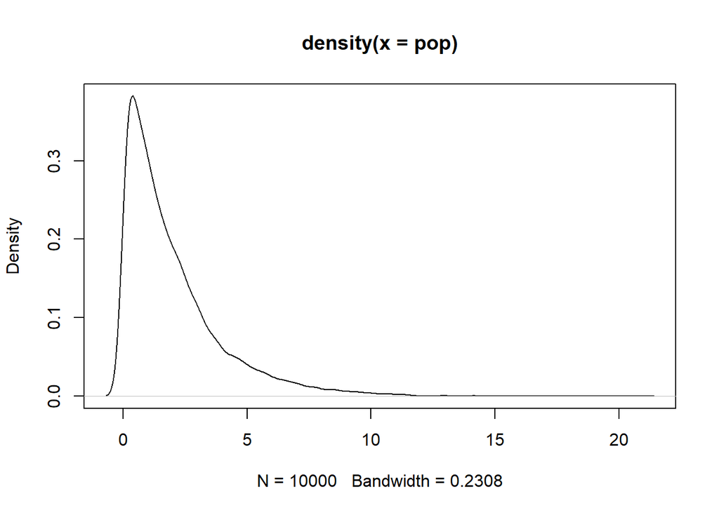

```r
pop <- rchisq(10000, df = 2)
plot(density(pop))
```

```r
mean_pop <- mean(pop)
print(paste("The mean in the population is ", round(mean(pop), digits = 4)))
```

```
[1] "The mean in the population is  1.9962"
```

```r
print(paste("The sd in the population is ", round(sd(pop), digits = 4)))
```

```
[1] "The sd in the population is  1.9908"
```

Let’s draw a sample with size 100 from that population and calculate its mean:

```r
mean(sample(pop, size = 100, replace = FALSE))
```

```
[1] 2.093954
```

If we would have had another sample, the mean would have been different:

```r
mean(sample(pop, size = 100, replace = FALSE))
```

```
[1] 2.134897
```

To estimate the distribution of these means, we can use a simulation. We repeat `mean(sample(pop, size = 100, replace = FALSE))` many times and store the result for each time we estimate the mean from a new sample. From the central limit theorem, the mean of the distribution of these estimates will follow a normal distribution with mean equal to the true population mean 1.9962.

Before we run this simulation, we’ll create a vector to store the results. The length of this vector equals the number of samples we’ll use. For this simulation, we’ll use estimates from `n <- 1000` samples. We also have to determine the size of the sample. Here, we’ll sample 100 observations from `pop`: `sample_size <- 100`:

```r
n <- 1000
sample_size <- 100
mean_sample <- vector(mode = "numeric", length = n)
```

We can now run the simulation: draw a sample from the population (in `pop`) with size `sample_size`, calculate the mean of the sample and store the results in the vector `mean_sample` and repeat this procedure `n` times

```r
for (i in 1:n) {
  mean_sample[i] <- mean(sample(x = pop, size = sample_size, replace = FALSE))
}
```

We can now look at the results:

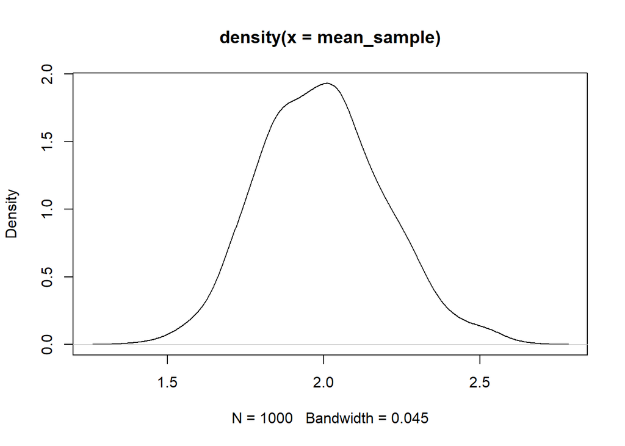

```r
plot(density(mean_sample))
```

```r
print(paste("The of the distribution is ", round(mean(mean_sample), digits = 4)))
```

```
[1] "The of the distribution is  1.9939"
```

```r
print(paste("The sd of the distribution is ", round(sd(mean_sample), digits = 4)))
```

```
[1] "The sd of the distribution is  0.199"
```

```r
print(paste("From the CLT, the sd of the distribution is ", round(sd(pop)/sqrt(sample_size), digits = 4)))
```

```
[1] "From the CLT, the sd of the distribution is  0.1991"
```

From the density, you can see that the vector with estimates of the mean using various samples, is a normal distribution. The mean of the distribution, 1.9939 is close to the population mean 1.9962.

```r
sample_size_vec <- c(100, 1000, 5000, 9999)
```

The first size is equal to the first simulation. The second and third are 1000 and 5000. The last more of less fully covers the true population: in each sample, only one member of the population is left out.

In addition to the size vector, we also need a container that can store the output of these runs. There are a couple of options: a matrix (with one column per sample size) or a list would be options. Here, we’ll use a list. The number of components should be equal to the number of various sample sizes. We’ll name the list using the sample size:

```r
mean_sample_size <- vector(mode = "list", length = length(sample_size_vec))
names(mean_sample_size) <- sample_size_vec
```

We now need a double loop: the inner loop is the same as the one for one sample size. The outer loop loops over the various sample sizes:

```r
for (j in seq_along(sample_size_vec)) {
  for (i in 1:n) {
    mean_sample_size[[j]][i] <- mean(sample(x = pop, size = sample_size_vec[j], replace = FALSE))
  }
}
```

```r
(sapply(mean_sample_size, mean) - mean_pop)/mean_pop * 100
```

```
          100          1000          5000          9999
 0.0006239030 -0.0319221540 -0.0204014913 -0.0004578047
```

```r
sapply(mean_sample_size, mean)
```

```
     100     1000     5000     9999
1.996232 1.995582 1.995812 1.996210
```

### 13.4.2 Using apply for the central limit theorem

Let’s try and rewrite the central limit theorem with one of the `apply()` functions. Here we will use `sapply()` to simulate the first case: 1000 simulations with a sample size of 100. The key to remember here is that `sapply()` applies a function to a vector or list. In other words, it uses the values in that list in the function. The function that we used was `mean(sample(x = pop, size = 100, replace = FALSE))`. In each simulation, the sample size was 100 and it repeated the function 1000 times. Recall the `rep(x = , times = )` function: it repeats the argument in `x`, `times` times. Using `rep(100, 1000)` produces a vector with 1000 elements, each equal to 100. If we use this in the `sample()` function, `sapply()` will use each of these elements to draw a new sample. All these samples will have the same size: 100. Each time, `sapply()` will calculate the mean and store the value in a vector, e.g. `mean_sample_sapply`. Using `sapply()`we can reduce the for loop to one line (using `\(y)` for the anonymous function to avoid confusion with the `x` argument in `rep`):

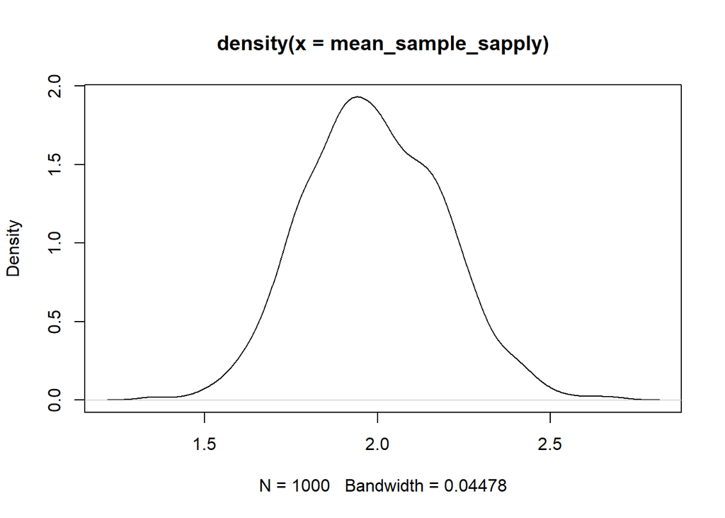

```r
mean_sample_sapply <- sapply(rep(100, 1000), \(y) mean(sample(x = pop, size = y)))

plot(density(mean_sample_sapply))
```

```r
print(paste("The of the distribution is ", round(mean(mean_sample_sapply), digits = 4)))
```

```
[1] "The of the distribution is  1.9899"
```

```r
print(paste("The sd of the distribution is ", round(sd(mean_sample_sapply), digits = 4)))
```

```
[1] "The sd of the distribution is  0.1981"
```

```r
print(paste("From the CLT, the sd of the distribution is ", round(sd(pop)/sqrt(sample_size), digits = 4)))
```

```
[1] "From the CLT, the sd of the distribution is  0.1991"
```

Using `vapply` you can specify the output, e.g. `numeric(1)` if you expect the output to return 1 value (as is the case here, per run 1 mean):

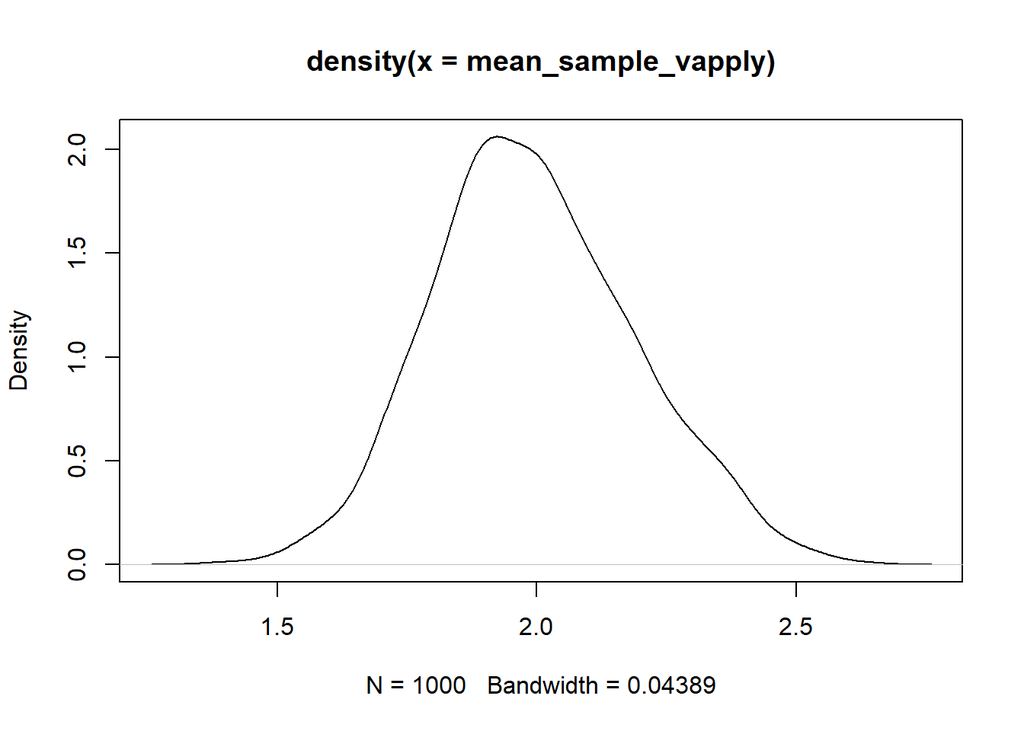

```r
mean_sample_vapply <- vapply(rep(100, 1000), \(y) mean(sample(x = pop, size = y)), FUN.VALUE = numeric(1))

plot(density(mean_sample_vapply))
```

```r
print(paste("The of the distribution is ", round(mean(mean_sample_vapply), digits = 4)))
```

```
[1] "The of the distribution is  1.9954"
```

```r
print(paste("The sd of the distribution is ", round(sd(mean_sample_vapply), digits = 4)))
```

```
[1] "The sd of the distribution is  0.1942"
```

```r
print(paste("From the CLT, the sd of the distribution is ", round(sd(pop)/sqrt(sample_size), digits = 4)))
```

```
[1] "From the CLT, the sd of the distribution is  0.1991"
```

```r
t_loop1 <- Sys.time()
n <- 100000
sample_size <- 100
mean_sample <- vector(mode = "numeric", length = n)
for (i in 1:n) {
  mean_sample[i] <- mean(sample(x = pop, size = sample_size, replace = FALSE))
}
t_loop2 <- Sys.time()

t_sapply1 <- Sys.time()

n <- 100000
sample_size <- 100
mean_sample_sapply <- vector(mode = "numeric", length = n)
mean_sample_sapply <- sapply(rep(sample_size, n), \(y) mean(sample(x = pop, size = y)))

t_sapply2 <- Sys.time()

t_vapply1 <- Sys.time()

n <- 100000
sample_size <- 100
mean_sample_vapply <- vector(mode = "numeric", length = n)
mean_sample_vapply <- vapply(rep(100, 1000), \(y) mean(sample(x = pop, size = y)), FUN.VALUE = numeric(1))

t_vapply2 <- Sys.time()

diff_loop = t_loop2 - t_loop1
diff_sapply = t_sapply2 - t_sapply1
diff_vapply = t_vapply2 - t_vapply1
```

| Procedure | Time |
| --- | --- |
| for loop | 2.06621313095093 |
| sapply | 2.12290191650391 |
| vapply | 0.0254909992218018 |

How would you code the second simulation with varying sample size? Here, the “inner” part, e.g. `vapply(rep(100, 1000), \(y) mean(sample(x = pop, size = y)), FUN.VALUE = numeric(1))` is a useful starting position. In this code, we need to allow for various values of the size of the sample. Each size value will generate a vector. With 4 sample sizes (100, 1000, 5000 and 9999), we need a container that can store 4 vectors. A list would be able to do so. How could we change the sample size and output a list? Using `lapply()` with `c(100, 1000, 5000, 9999)`, each of these values will be used in the function that will be applied by `lapply()`. Using `function(y) {vapply(rep(y, 1000), \(z) mean(sample(x = pop, size = z)), FUN.VALUE = numeric(1)))}` in `lapply` will do what we need: first it takes the value `100` and applies the function `vapply(rep(y, 1000), \(z) mean(sample(x = pop, size = z)), FUN.VALUE = numeric(1)))`, the values are stored as a vector in a list. `lapply()` then moves to the second value (`1000`) and uses it in the function, … :

```r
mean_sample_lapply <- lapply(sample_size_vec,
                             function(y) {
                               vapply(rep(y, 1000),
                                      function(z) mean(sample(x = pop, size = z)), FUN.VALUE = numeric(1))})

sapply(mean_sample_lapply, sd)
```

```
[1] 0.1918556976 0.0601548664 0.0196456091 0.0002199419
```

```r
sapply(mean_sample_lapply, mean)
```

```
[1] 1.994668 1.994444 1.996723 1.996215
```

### 13.4.3 Lottery using a for loop

What are the odds? Suppose that you have a lottery where each time the lottery is played 6 numbers are drawn (without replacement) from a sequence with 45 numbers, starting at 1 and ending at 45 in steps of 1. The lottery is fair, i.e. every number has the same probability of being drawn. Every time, you buy a ticket with the same 6 numbers. If you ticket has 3 correct number, you win 20; if your ticket has 4 correct numbers you win 50; with 5 correct numbers you win 5000 and if all six are correct, you win 1 million. With only 2, 1 or 0 correct numbers, you don’t win at all. To estimate the probability that you win the “big” ticket (1 million) or your expected payoff if you play this lottery many times, we can use a simulation.

Let’s first define the potential outcomes (numbers and payour) and your ticket:

```r
# All possible numbers:
numbers <- seq(1:45)

# Fixed ticket: 6 drawn at random from 1:45
ticket <- sample(numbers, 6, replace = FALSE)

# Payout
payout <- c(0, 0, 0, 20, 50, 5000, 1000000)
names(payout) <- paste0("correct_", 0:6)
```

Suppose that you are 18 years old, you expect to live a another 70 years and the lottery is played two times a week. You’ll play a total of 7280 times

```r
n = 70 * 52 * 2
```

Let’s now turn to the simulation. You are interested in the number of times you’ll have 0, 1, 2, … 6 correct numbers. To store that information, we’ll create a vector `wins` with 7 elements.

```r
wins <- rep(0, 7)
names(wins) <- paste0("correct_", 0:6)
```

We can now play the lottery. To do so, we first draw a sample of 6 numbers from `numbers`. This is the weekly draw. Using that weekly draw, we compare your ticket with the draw and calculate how many correct numbers you had. If you didn’t have a single correct number, we increase the value in `wins[1]` with 1, if you had 1 correct number, we increase the value in `wins[2]` with 1, … . To make sure that we always start from a `wins` vector with zeroes, I’ll start with setting the values in `wins` to 0:

```r
for (i in seq_along(wins)) {wins[i] <- 0}


for (i in 1:n) {
  draw <- sample(numbers, 6, replace = FALSE) #weekly draw of the winning numbers
  w <- sum(ticket %in% draw) # alternative: length(intersect(ticket, draw))
  wins[w + 1] <- wins[w + 1] + 1 #use the observation that w = 0, 1, 2 ... 5 or 6 to subset the wins vector
}
```

Note that you can shorten this code (you don’t need the `draw`):

```r
for (i in 1:n) {
  w <- sum(ticket %in% sample(numbers, 6, replace = FALSE))
  wins[w + 1] <- wins[w + 1] + 1
}
```

We can now look at the outcome:

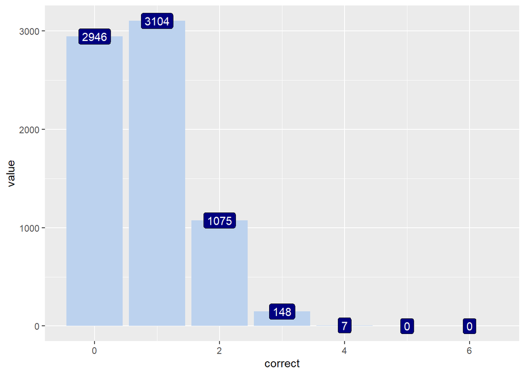

and calculate your expected outcome:

```r
expected_outcome = sum(payout * wins)
```

In other words, your expected outcome is negative is you pay more than

```r
expected_outcome / n
```

```
[1] 0.4546703
```

per play. To be profitable, the lottery must at least charge this amount. On average, you would win

```r
sum(wins[4:7]) / 70
```

```
[1] 2.214286
```

per year

### 13.4.4 Lottery using the `apply()`family

We can shorten the `for` loop. However, before we do so, we need to introduce the `table()` function:

```r
table(...,
      exclude = if (useNA == "no") c(NA, NaN),
      useNA = c("no", "ifany", "always"),
      dnn = list.names(...), deparse.level = 1)
```

This function return a contingency table and show how many times the various values in an object in `...` occur. The object must be interpretable as a factor. The arguments `exclude` and `useNA` allow to specify what has to happen with `NA` values.

Using `sapply()` we can create a vector with the number of wins in each draw:

```r
n = 70 * 52 * 2
wins_sapply <- sapply(rep(6, n), \(x) (sum(ticket %in% sample(numbers, x, replace = FALSE))))
```

Using `table()` you can count the number of times the ticket had 0, 1, 2, …. correct numbers

```r
table(wins_sapply)
```

```
wins_sapply
   0    1    2    3    4
2906 3079 1105  174   16
```

In one line of code:

```r
wins_sapply_table <- table(sapply(rep(6, n), \(x) (sum(ticket %in% sample(numbers, x, replace = FALSE)))))
```

### 13.4.5 Estimating pi

To estimate pi, we’ll use a simulation. The idea for this simulation is quite simple. Consider the following circle and square:

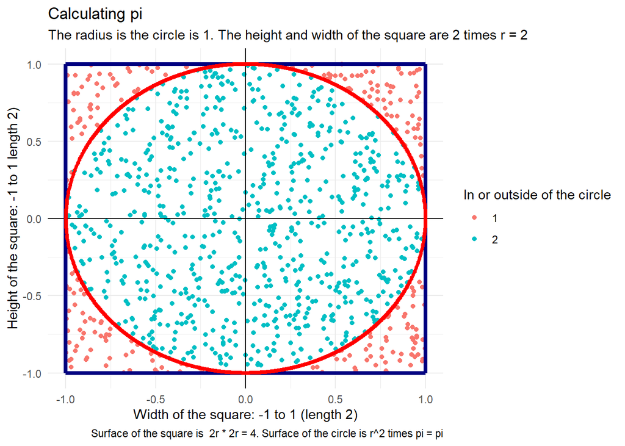

$$2r * 2r = 4r^2 = 4$$

The circle covers
$$\frac{\pi}{4}$$
of the square.

Suppose now that we put dots at random places in the square. Some dots will be in the circle while other will not. In the figure, the orange dots are in the square, but not in the circle; green dots are in the circle (and obviously also in the square). If we put 1000 dots in the square, you could expect that the number of dots in the circle will be proportional to area of the square that is covered by the circle. In other words
$$\frac{\text{dots in circle}}{\text{dots total (in and outside the circle)}} = \frac{\pi}{4}$$

Using this observation, we can simulate pi.

To illustrate, consider the following case

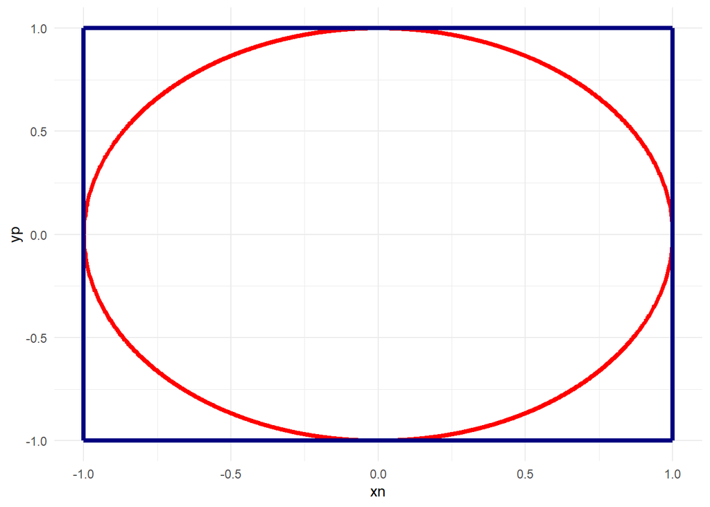

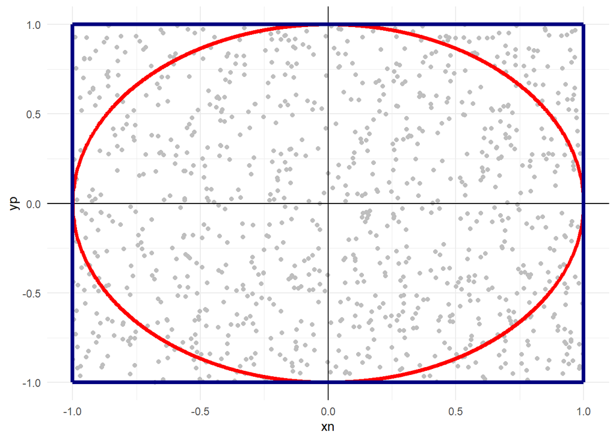

```
Ignoring unknown labels:
• colour : "In or outside of the circle"
```

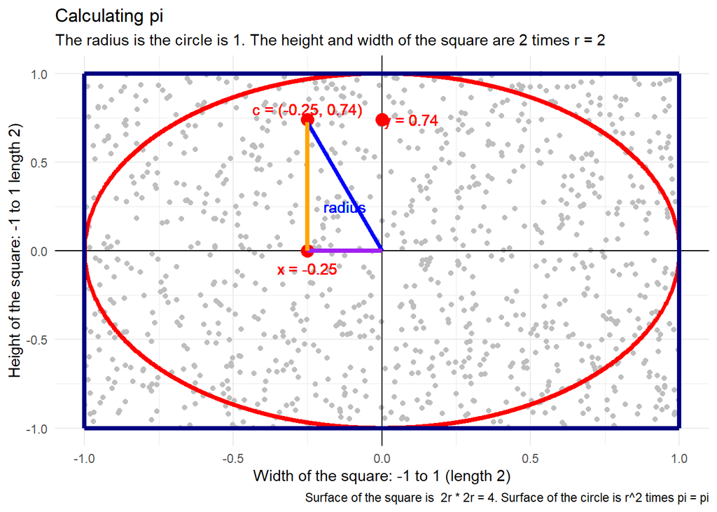

- a random draw from a uniform distribution between -1 and 1 (x-axis) (e.g. -0.25)
- a random draw from a uniform distribution between -1 and 1 (y-axis) (e.g. 0.74)
- we now have a dot, c with position (-0.25, 0.74)
- using the pythagorean theorem we can calculate the radius of c as sqrt(x^2 + y^2) (blue line)
- as we have a unit circle, we now that all points with a radius smaller then or equal to 1 are part of the unit circle while all other points are not
- repeat this for many points and calculate how many of them are in the circle
- calculate the estimate of pi using

$$4 * \frac{\text{dots in circle}}{\text{dots total (in and outside the circle)}} = \pi$$

We’ll use two procedure to estimate pi in this way. The first uses a for loop: - generate values for x and y from a uniform distribution with mininimum -1 and maximum 1 - calculate c - if c is smaller than or equal to 1, increase the counter `in_cirle` with 1, draw new value of x - repeat this loop `n` times - calculate pi as

$$\text{est_pi} = 4 * \frac{\text{in_circle}}{n}$$
The second uses the fact that R is vectorized: - generate a vector `x` with `n` draws from a uniform distribution with minimum -1 and maximum 1 - generate a vector `y` with `n` draws from a uniform distribution with minimum -1 and maximum 1 - calculate `c = sqrt(x^2 + y^2) - use`sum(c <= 1)`to calculate`in_circle_vector` - calculate pi as
$$\text{est_pi} = 4 * \frac{\text{in_circle_vector}}{n}$$
For both procedures the output shows the estimate of pi, the error and the time it took to complete both. The size of the simulation is equal in both (n = 1 million). - for loop

```r
# start clock

t1l <- Sys.time()

# set values: number of runs and the counter for in_circle
n <- 1000000
in_circle <- 0

# loop
for (i in 1:n) {
  x <- runif(1, -1, 1)     # generate x value
  y <- runif(1, -1, 1)     # generate y value
  c <- sqrt(x^2 + y^2)     # calculate c

  if (c <= 1) {
    in_circle <- in_circle + 1 # if in circle, add 1 to in_circle
  }
}

# estimate of pi
pi_estl <- 4 * (in_circle/(n)) # estimate of pi

# difference between estimate and real value
pi_errl <- (pi_estl - pi)/pi * 100

# stop the clock
t2l <- Sys.time()

# calculate and show the results

tloop <- t2l - t1l

print(paste0("The estimated value of pi = ", pi_estl,
             " and the error equals ", pi_errl, "%."))
```

```
[1] "The estimated value of pi = 3.140764 and the error equals -0.0263768629852872%."
```

```r
print(paste0("Running this code took ", tloop, " seconds"))
```

```
[1] "Running this code took 0.914984941482544 seconds"
```

- Using vectorization

```r
# start clock
t1v <- Sys.time()

# set values: number of runs and the counter for in_circle
n <- 1000000
in_circle_vector <- 0

# create the vectors x, y and calculate c
x <- runif(n = n, min = -1, max = 1)
y <- runif(n = n, min = -1, max = 1)
c <- sqrt(x^2 + y^2)

# determine the number of points in the circle:
in_circle_vector <- sum(c <= 1)

# estimate of pi
pi_estv <-  4*in_circle_vector/n

# difference between estimate and real value
pi_errv <- (pi_estv - pi)/pi * 100


# stop the clock
t2v <- Sys.time()

# calculate and show the results

tvec <- t2v - t1v


print(paste0("The estimated value of pi = ", pi_estv,
             " and the error equals ", pi_errv, "%."))
```

```
[1] "The estimated value of pi = 3.140604 and the error equals -0.0314698211642188%."
```

```r
print(paste0("Running this code took ", tvec, " seconds"))
```

```
[1] "Running this code took 0.041262149810791 seconds"
```

As you can see from the results, both generate about the same error, but the vector approach is much faster than the loop.

| Procedure | Estimate of Pi | Error of estimate | Duration in seconds |
| --- | --- | --- | --- |
| loop | 3.140764000 | −0.0264% | 0.914984941482544 |
| vector | 3.140604000 | −0.0315% | 0.041262149810791 |